# Renewvia - Survey Impact Analysis

# OVERVIEW: HYPOTHESIS TESTING

**Strategy**:

- For the paired data set, we will use the Paired t-Test, Wilcoxon Signed Rank Test, Sign Test, and McNemar’s Test whenever applicable
- Our independent variables will be the following: PV Size (kWh), No. of Customers, CAPEX (USD) and Consumption (Community & Customer).
- For each dependent variables, we will run a uni-variate regression tests with each of independent variable. When applicable, we will have a Linear regression t-Test or Logistic regression Wald test

# Importing libraries

```r
library(ggplot2)
library(dplyr)
library(lessR)
library(tidyr)
library(ggpubr)
library(exact2x2)
library(stringr)
library(janitor)
library(epiDisplay)
library(nonpar)
library(tibble)
library(ggExtra)
```

# Loading the data sets

```r
## Locading the project data
projects <- read.csv("project_data.csv")
head(projects)
```

|  | project_name | community | country | pv_size_kwh | customer_count | capex_usd |
| --- | --- | --- | --- | --- | --- | --- |
| 1 | Kalobeyei Settlement | kalobeyei_settlement | Kenya | 541.40 | 2755 | 967872 |
| 2 | Ndeda | ndeda | Kenya | 23.40 | 405 | 197853 |
| 3 | Emereoke | emereoke | Nigeria | 28.08 | 401 | 336197 |
| 4 | Akipelai | akipelai | Nigeria | 67.32 | 355 | 323701 |
| 5 | Locheremoit | locheremoit | Kenya | 37.00 | 329 | 311220 |
| 6 | Oloibiri | oloibiri | Nigeria | 67.32 | 321 | 346464 |

```r
## Locading the cleaned data sets
# Intial Survey
initial_clean <- read.csv("data_cleaning/datasets_clean/initial_clean.csv")%>%
                    filter(renewvia_id != "") %>%
                    filter(renewvia_id != "no_meter")

# Pre-connection
intial_hs_pre <- initial_clean %>%
                    filter(status == "pre_connection")%>%
                    filter(tariff == "residential")

# Pre-connection
intial_hs_post <- initial_clean %>%
                    filter(status == "post_connection")%>%
                    filter(tariff == "residential")

head(initial_clean)
```

|  | X | status | connection_period_initial | renewvia_id | country | nigeria_community | kenya_community | age | gender | occupation | primary_provider | primary_provider_occupation | employement_type | avg_household_income | household_headcount | adult_headcount | girls_headcount | boys_headcount | girls_age | boys_age | girls_schooling | girls_unschooled_reasons | boys_schooling | boys_unschooled_reasons | household_business_owners | minigrid_signup_primary_reason | minigrid_signup_secondary_reason | power_sources | power_sources_usage | … |
| --- | --- | --- | --- | --- | --- | --- | --- | --- | --- | --- | --- | --- | --- | --- | --- | --- | --- | --- | --- | --- | --- | --- | --- | --- | --- | --- | --- | --- | --- | --- |
| 1 | 0 | pre_connection |  | 501121 | nigeria | akipelai |  |  |  |  |  |  |  | NA | NA | NA | NA | NA |  |  | NA |  | NA |  |  |  |  |  |  | … |
| 2 | 1 | pre_connection | 3_6_months | 5763 | nigeria | balep |  | 45 | male | farming | yes |  | seasonal_self_employed | 27 | 3 | 2 | NA | 1 |  | older_than_16 | NA |  | 1 |  | adult_female | ability_to_earn_more_money | reliable_access_to_light | petrol_generator | between_5_8_hours | … |
| 3 | 2 | pre_connection | 3_6_months | 5728 | nigeria | balep |  | 52 | male | education | yes |  | regular_self_employed | 30 | 9 | 7 | 2 | 5 | 16;older_than_16 | older_than_16 | 2 |  | 4 |  | adult_female | ability_to_earn_more_money | reliable_access_to_light | petrol_generator | between_5_8_hours | … |
| 4 | 4 | pre_connection | 3_6_months | 5797 | nigeria | balep |  | 27 | male | education | no | farming | seasonal_self_employed | 38 | 7 | 7 | 2 | 3 | older_than_16 | older_than_16 | 2 |  | 3 |  |  | reliable_access_to_light | ability_to_earn_more_money | solar_home_kit | more_than_8_hours | … |
| 5 | 5 | pre_connection |  | 5746 | nigeria | balep |  | 30 | male | education | yes | education | seasonal_self_employed | 30 | 3 | 2 | 1 | NA | 2 |  | NA | not_old_enough | NA |  |  | reliable_access_to_light;ability_to_charge_mobile_phone(s | increased_hours_of_productivity_business_studying_etc | petrol_generator | between_2_5_hours | … |
| 6 | 6 | pre_connection |  | 5724 | nigeria | balep |  | 43 | male | farming | yes | farming | regular_non_self_employed | 15 | 12 | 8 | 1 | 3 | older_than_16 | 12;older_than_16 | NA | they_all_attend_school_full_time | NA | they_all_attend_school | adult_male | ability_to_charge_mobile_phone(s;security_of_property_home_possessions | ability_to_start_a_business | petrol_generator | between_2_5_hours | … |

```r
head(intial_hs_pre)
```

|  | X | status | connection_period_initial | renewvia_id | country | nigeria_community | kenya_community | age | gender | occupation | primary_provider | primary_provider_occupation | employement_type | avg_household_income | household_headcount | adult_headcount | girls_headcount | boys_headcount | girls_age | boys_age | girls_schooling | girls_unschooled_reasons | boys_schooling | boys_unschooled_reasons | household_business_owners | minigrid_signup_primary_reason | minigrid_signup_secondary_reason | power_sources | power_sources_usage | … |
| --- | --- | --- | --- | --- | --- | --- | --- | --- | --- | --- | --- | --- | --- | --- | --- | --- | --- | --- | --- | --- | --- | --- | --- | --- | --- | --- | --- | --- | --- | --- |
| 1 | 0 | pre_connection |  | 501121 | nigeria | akipelai |  |  |  |  |  |  |  | NA | NA | NA | NA | NA |  |  | NA |  | NA |  |  |  |  |  |  | … |
| 2 | 1 | pre_connection | 3_6_months | 5763 | nigeria | balep |  | 45 | male | farming | yes |  | seasonal_self_employed | 27 | 3 | 2 | NA | 1 |  | older_than_16 | NA |  | 1 |  | adult_female | ability_to_earn_more_money | reliable_access_to_light | petrol_generator | between_5_8_hours | … |
| 3 | 2 | pre_connection | 3_6_months | 5728 | nigeria | balep |  | 52 | male | education | yes |  | regular_self_employed | 30 | 9 | 7 | 2 | 5 | 16;older_than_16 | older_than_16 | 2 |  | 4 |  | adult_female | ability_to_earn_more_money | reliable_access_to_light | petrol_generator | between_5_8_hours | … |
| 4 | 4 | pre_connection | 3_6_months | 5797 | nigeria | balep |  | 27 | male | education | no | farming | seasonal_self_employed | 38 | 7 | 7 | 2 | 3 | older_than_16 | older_than_16 | 2 |  | 3 |  |  | reliable_access_to_light | ability_to_earn_more_money | solar_home_kit | more_than_8_hours | … |
| 5 | 5 | pre_connection |  | 5746 | nigeria | balep |  | 30 | male | education | yes | education | seasonal_self_employed | 30 | 3 | 2 | 1 | NA | 2 |  | NA | not_old_enough | NA |  |  | reliable_access_to_light;ability_to_charge_mobile_phone(s | increased_hours_of_productivity_business_studying_etc | petrol_generator | between_2_5_hours | … |
| 6 | 6 | pre_connection |  | 5724 | nigeria | balep |  | 43 | male | farming | yes | farming | regular_non_self_employed | 15 | 12 | 8 | 1 | 3 | older_than_16 | 12;older_than_16 | NA | they_all_attend_school_full_time | NA | they_all_attend_school | adult_male | ability_to_charge_mobile_phone(s;security_of_property_home_possessions | ability_to_start_a_business | petrol_generator | between_2_5_hours | … |

```r
head(intial_hs_post)
```

|  | X | status | connection_period_initial | renewvia_id | country | nigeria_community | kenya_community | age | gender | occupation | primary_provider | primary_provider_occupation | employement_type | avg_household_income | household_headcount | adult_headcount | girls_headcount | boys_headcount | girls_age | boys_age | girls_schooling | girls_unschooled_reasons | boys_schooling | boys_unschooled_reasons | household_business_owners | minigrid_signup_primary_reason | minigrid_signup_secondary_reason | power_sources | power_sources_usage | … |
| --- | --- | --- | --- | --- | --- | --- | --- | --- | --- | --- | --- | --- | --- | --- | --- | --- | --- | --- | --- | --- | --- | --- | --- | --- | --- | --- | --- | --- | --- | --- |
| 1 | 1134 | post_connection | 6_12_months | 161148 | kenya |  | oyamo | 28 | male |  | yes | fishing | regular_non_self_employed | 8 | 5 | 2 | 2 | 1 | 4;10;16; | 2; | 2 | health_reasons | 1 | other |  | reliable_access_to_light | security_of_property_home_possessions | solar_home_kit; | between_2_and_5_hours | … |
| 2 | 1136 | post_connection | 6_12_months | 161078 | kenya |  | oyamo | 28 | male |  | yes | fishing | regular_non_self_employed | 5 | 5 | 2 | 2 | 1 | 3;6; | 3;7; | 2 | health_reasons | 1 | health_reasons | adult_female; | reliable_access_to_light | ability_to_start_a_new_business | solar_home_kit; | between_2_and_5_hours | … |
| 3 | 1138 | post_connection | 6_12_months | 161041 | kenya |  | oyamo | 29 | male |  | yes | fishing | seasonal_self_employed | 10 | 4 | 2 | 1 | 2 | 2; | 1;3; | 1 | health_reasons | 1 | childcare |  | reliable_access_to_light | ability_to_start_a_new_business | solar_home_kit; | between_2_and_5_hours | … |
| 4 | 1141 | post_connection | 6_12_months | 161044 | kenya |  | oyamo | 37 | male |  | yes | fishing | seasonal_self_employed | 10 | 5 | 2 | 1 | 2 | 2; | 5;14; | 1 | childcare | 2 | lacking_money_for_school_fees | adult_female; | reliable_access_to_light | possibility_to_purchase_a_tv | solar_home_kit; | between_5_and_8_hours | … |
| 5 | 1143 | post_connection | 6_12_months | 161030 | kenya |  | oyamo | 35 | female |  | yes | fishing | regular_non_self_employed | 6 | 5 | 2 | 0 | 3 | 1; | 11;16;older_than_16; | 0 | other | 3 | lacking_money_for_school_fees |  | reliable_access_to_light | possibility_to_purchase_a_tv | solar_home_kit; | between_5_and_8_hours | … |
| 6 | 1146 | post_connection | 6_12_months | 161149 | kenya |  | oyamo | 56 | female |  | yes | farming | seasonal_self_employed | 3 | 4 | 1 | 2 | 1 | 5;15; | 5; | 2 | lacking_money_for_school_fees | 1 | health_reasons |  | reliable_access_to_light | security_of_property_home_possessions | solar_home_kit; | between_2_and_5_hours | … |

```r
# Household Post-Survey
post_clean <- read.csv("data_cleaning/datasets_clean/hs_post_clean.csv")%>%
                    filter(renewvia_id != "") %>%
                    filter(renewvia_id != "no_meter")
# Post-Connection
post_hs <- post_clean %>% filter(tariff == "residential")
head(post_clean)
```

|  | X | renewvia_id | interviewed_before | connection_period | country | nigeria_community | kenya_community | age | gender | occupation_change | household_income_change | avg_household_income | household_headcount_change | girls_schooling_change | boys_schooling_change | school_performance_change | girls_unschooled_reasons | boys_unschooled_reasons | household_business_owners | business_type | business_recent | business_from_minigrid | business_use_minigrid | power_sources | power_sources_usage | power_sources_primary | appliances_count | appliances_count_change | cellphones_count | … |
| --- | --- | --- | --- | --- | --- | --- | --- | --- | --- | --- | --- | --- | --- | --- | --- | --- | --- | --- | --- | --- | --- | --- | --- | --- | --- | --- | --- | --- | --- | --- |
| 1 | 0 | 131230 | no | 12_24_months | kenya |  | kalobeyei_settlement | 52 | male | yes | yes_it_has_increased | 2 | yes_its_increased | no_its_the_same | no_its_the_same | yes_its_gotten_better | they_all_attend_school | they_all_attend_school | adult_male; | shop | yes | yes | yes | minigrid_electricity_renewvia; | between_5_and_8_hours | minigrid_electricity_renewvia | 1 | yes | 2 | … |
| 2 | 1 | 131543 | no | 12_24_months | kenya |  | kalobeyei_settlement | 30 | female | no | no_it_is_the_same | 2 | no | yes_its_increased | no_its_the_same | no_its_the_same | not_old_enough | they_all_attend_school |  | no_business | yes | yes | no | solar_home_kit;not_available_; | between_5_and_8_hours | not_available | NA | yes | 2 | … |
| 3 | 2 | 131273 | yes | over_36_months | kenya |  | kalobeyei_settlement | 33 | male | yes | yes_it_has_increased | 3 | yes_its_increased | no_its_the_same | no_its_the_same | yes_its_gotten_better | they_all_attend_school | they_all_attend_school |  | yes | no | yes | no | charcoal; | less_than_2_hours | solar_home_kit | 3 | yes | 1 | … |
| 4 | 3 | 131140 | no | 12_24_months | kenya |  | kalobeyei_settlement | 30 | female | yes | yes_it_has_increased | 2 | no | yes_its_increased | no_its_the_same | no_its_the_same | they_all_attend_school | not_old_enough |  | no_business | no |  | no | solar_home_kit; | between_2_and_5_hours | minigrid_electricity_renewvia | 3 | yes | 2 | … |
| 5 | 4 | 131117 | yes | 12_24_months | kenya |  | kalobeyei_settlement | 32 | female | yes | no_it_is_the_same | 1 | no | yes_its_increased | no_its_the_same | no_its_the_same | they_all_attend_school | they_all_attend_school |  | no_business | yes | yes | yes | solar_home_kit;not_available_; | less_than_2_hours | not_available | 24 | yes | 3 | … |
| 6 | 5 | 131117 | yes | 12_24_months | kenya |  | kalobeyei_settlement | 32 | female | yes | no_it_is_the_same | 1 | no | yes_its_increased | no_its_the_same | no_its_the_same | they_all_attend_school | they_all_attend_school |  | no_business | yes | yes | yes | solar_home_kit;not_available_; | less_than_2_hours | not_available | 24 | yes | 3 | … |

```r
head(post_hs)
```

|  | X | renewvia_id | interviewed_before | connection_period | country | nigeria_community | kenya_community | age | gender | occupation_change | household_income_change | avg_household_income | household_headcount_change | girls_schooling_change | boys_schooling_change | school_performance_change | girls_unschooled_reasons | boys_unschooled_reasons | household_business_owners | business_type | business_recent | business_from_minigrid | business_use_minigrid | power_sources | power_sources_usage | power_sources_primary | appliances_count | appliances_count_change | cellphones_count | … |
| --- | --- | --- | --- | --- | --- | --- | --- | --- | --- | --- | --- | --- | --- | --- | --- | --- | --- | --- | --- | --- | --- | --- | --- | --- | --- | --- | --- | --- | --- | --- |
| 1 | 0 | 131230 | no | 12_24_months | kenya |  | kalobeyei_settlement | 52 | male | yes | yes_it_has_increased | 2 | yes_its_increased | no_its_the_same | no_its_the_same | yes_its_gotten_better | they_all_attend_school | they_all_attend_school | adult_male; | shop | yes | yes | yes | minigrid_electricity_renewvia; | between_5_and_8_hours | minigrid_electricity_renewvia | 1 | yes | 2 | … |
| 2 | 1 | 131543 | no | 12_24_months | kenya |  | kalobeyei_settlement | 30 | female | no | no_it_is_the_same | 2 | no | yes_its_increased | no_its_the_same | no_its_the_same | not_old_enough | they_all_attend_school |  | no_business | yes | yes | no | solar_home_kit;not_available_; | between_5_and_8_hours | not_available | NA | yes | 2 | … |
| 3 | 2 | 131273 | yes | over_36_months | kenya |  | kalobeyei_settlement | 33 | male | yes | yes_it_has_increased | 3 | yes_its_increased | no_its_the_same | no_its_the_same | yes_its_gotten_better | they_all_attend_school | they_all_attend_school |  | yes | no | yes | no | charcoal; | less_than_2_hours | solar_home_kit | 3 | yes | 1 | … |
| 4 | 3 | 131140 | no | 12_24_months | kenya |  | kalobeyei_settlement | 30 | female | yes | yes_it_has_increased | 2 | no | yes_its_increased | no_its_the_same | no_its_the_same | they_all_attend_school | not_old_enough |  | no_business | no |  | no | solar_home_kit; | between_2_and_5_hours | minigrid_electricity_renewvia | 3 | yes | 2 | … |
| 5 | 4 | 131117 | yes | 12_24_months | kenya |  | kalobeyei_settlement | 32 | female | yes | no_it_is_the_same | 1 | no | yes_its_increased | no_its_the_same | no_its_the_same | they_all_attend_school | they_all_attend_school |  | no_business | yes | yes | yes | solar_home_kit;not_available_; | less_than_2_hours | not_available | 24 | yes | 3 | … |
| 6 | 5 | 131117 | yes | 12_24_months | kenya |  | kalobeyei_settlement | 32 | female | yes | no_it_is_the_same | 1 | no | yes_its_increased | no_its_the_same | no_its_the_same | they_all_attend_school | they_all_attend_school |  | no_business | yes | yes | yes | solar_home_kit;not_available_; | less_than_2_hours | not_available | 24 | yes | 3 | … |

```r
# Commercial & Insitution Post-Survey
ci_clean <- read.csv("data_cleaning/datasets_clean/ci_post_clean.csv") %>%
                    filter(renewvia_id != "") %>%
                    filter(renewvia_id != "no_meter") %>%
                    filter(tariff == "commercial")
head(ci_clean)
```

|  | X | Unnamed..0 | start | end | renewvia_id | country | kenya_community | nigeria_community | original_person | connection_period_non_original_subscriber | first_name | last_name | connection_period | business_type | institution_name | operation_status | closed_operations_explain | non_renewvia_electrical_sources | appliances_addition_type | appliances_addition_explain | kerosene_usage_change | diesel_usage_change | operations_hours_change | business_hours_increase | clean_drinking_water_access | ci_offering_change | new_prod_serv_add_explain | workforce_change | workforce_change_explain | … |
| --- | --- | --- | --- | --- | --- | --- | --- | --- | --- | --- | --- | --- | --- | --- | --- | --- | --- | --- | --- | --- | --- | --- | --- | --- | --- | --- | --- | --- | --- | --- |
| 1 | 0 | 0 | 2022_07_20_04:18:02 | 2022_07_20_04:24:28 | 131206 | kenya | kalobeyei_settlement |  |  |  |  |  | longer_than_2_years | shop | business |  |  | no_just_renewvia_minigrid | cold_storage__refrigerator_or_freezer;computer_or_tv;fan; | fridges_tv_fan | yes_it_has_decreased | yes_it_has_decreased | yes_they_have_increased | 1_2_hours_daily | yes_it_has_increased | yes | the_connection_of_the_renewvia_maingrid_has_improve_my_income_and_change_my_life | no_the_number_has_remained_the_same | no | … |
| 2 | 1 | 1 | 2022_07_20_04:55:11 | 2022_07_20_05:01:23 | 131231 | kenya | kalobeyei_settlement |  |  |  |  |  | longer_than_2_years | other_business | business |  |  | no_just_renewvia_minigrid | cold_storage__refrigerator_or_freezer;exterior_lights;interior_lights;computer_or_tv; | not_available | yes_it_has_decreased | yes_it_has_decreased | yes_they_have_increased | 1_2_hours_daily | yes_it_has_increased | yes | fridge_tv | yes_we_have_added_workers | added_two_employees | … |
| 3 | 2 | 2 | 2022_07_20_05:03:46 | 2022_07_20_05:12:06 | 131542 | kenya | kalobeyei_settlement |  |  |  |  |  | longer_than_2_years | shop | business |  |  | no_just_renewvia_minigrid | cold_storage__refrigerator_or_freezer; | refridgirators | yes_it_has_decreased | yes_it_has_decreased | yes_they_have_increased | 1_2_hours_daily | yes_it_has_increased | yes | refridgirator | no_the_number_has_remained_the_same | not_available | … |
| 4 | 3 | 3 | 2022_07_20_05:12:18 | 2022_07_20_05:42:12 | 131220 | kenya | kalobeyei_settlement |  |  |  |  |  | longer_than_2_years | shop | business |  |  | no_just_renewvia_minigrid | cold_storage__refrigerator_or_freezer;computer_or_tv;other_electronic_device;interior_lights;exterior_lights; | radio_refridgirators_tv_ | yes_it_has_increased | yes_it_has_increased | yes_they_have_increased | 2_4_hours_daily | yes_it_has_increased | yes | radio_tv_refridgirators | yes_we_have_added_workers | 2 | … |
| 5 | 4 | 4 | 2022_07_20_05:42:21 | 2022_07_20_05:47:14 | 131485 | kenya | kalobeyei_settlement |  |  |  |  |  | longer_than_2_years | shop | business |  |  | no_just_renewvia_minigrid | no_additional_appliances; |  | yes_it_has_decreased | yes_it_has_decreased | yes_they_have_increased | 1_2_hours_daily | yes_it_has_increased | no | not_available | no_the_number_has_remained_the_same | 1 | … |
| 6 | 5 | 5 | 2022_07_20_05:47:21 | 2022_07_20_06:02:03 | 131107 | kenya | kalobeyei_settlement |  |  |  |  |  | longer_than_2_years | shop | business |  |  | no_just_renewvia_minigrid | interior_lights;exterior_lights;computer_or_tv;other_electronic_device; | radio | yes_it_has_decreased | yes_it_has_decreased | yes_they_have_increased | 1_2_hours_daily | yes_it_has_increased | yes | tv_radio | no_the_number_has_remained_the_same | not_available | … |

```r
## Locading the encoded data sets
# Intial Survey
initial_enc <- read.csv("data_cleaning/datasets_encoded/initial_encoded.csv")%>%
                    filter(renewvia_id != "") %>%
                    filter(renewvia_id != "no_meter")

# Pre-connection
intial_hs_pre_enc <- initial_enc %>%
                    filter(status == 1)%>%
                    filter(tariff == "residential")

# Pre-connection
intial_hs_post_enc <- initial_enc %>%
                    filter(status == 2)%>%
                    filter(tariff == "residential")

head(initial_enc)
```

|  | X | renewvia_id | community | tariff | age | gender | status | connection_period_initial | avg_household_income | minigrid_signup_primary_reason | light_hours_current | light_primary_sources | kerosene_lamps_count | kerosene_lamp_usage_time | kerosene_lamps_cost | cooking_energy_sources | cooking_energy_sources.1 | cooking_fuel_collection_time | cooking_fuel_responsible | cooking_energy_cost | feel_safe_dark | community_lights | home_exterior_lights | feel_safe_if_exterior_lights | feel_unsafe_reasons | clean_drinking_water | clean_drinking_water_source | clean_water_source | water_collection_travel_distance | … |
| --- | --- | --- | --- | --- | --- | --- | --- | --- | --- | --- | --- | --- | --- | --- | --- | --- | --- | --- | --- | --- | --- | --- | --- | --- | --- | --- | --- | --- | --- | --- |
| 1 | 0 | 501121 | akipelai | residential |  | NA | 1 | NA | NA |  | NA |  | NA | NA | NA | NA | NA | NA |  | NA | NA |  | NA | NA | NA | NA | NA |  | NA | … |
| 2 | 1 | 5763 | balep | residential | 45 | 2 | 1 | 2 | 27 | 6 | 5 | 1 | NA | NA | NA | 3 | 3 | 3 | 2 | 1 | 5 | 2 | 0 | 1 | 2 | 1 | 2 | bottle_water | 1 | … |
| 3 | 2 | 5728 | balep | residential | 52 | 2 | 1 | 2 | 30 | 6 | 5 | 2 | NA | NA | NA | 2 | 2 | 2 | 1 | 5 | 5 | 2 | 0 | 1 | 2 | 1 | 1 | boiled_water | 1 | … |
| 4 | 4 | 5797 | balep | residential | 27 | 2 | 1 | 2 | 38 | 1 | 6 | 2 | NA | NA | NA | 6 | 6 | 3 | 2 | 5 | 5 | 2 | 0 | 1 | 1 | 1 | 2 | bottle_water | 2 | … |
| 5 | 5 | 5746 | balep | residential | 30 | 2 | 1 | NA | 30 | reliable_access_to_light;ability_to_charge_mobile_phone(s | 4 | 2 | NA | NA | NA | 3 | 3 | 3 | 2 | 2 | 5 | 1 | 0 | 1 | 2 | 0 | 1 |  | 1 | … |
| 6 | 6 | 5724 | balep | residential | 43 | 2 | 1 | NA | 15 | ability_to_charge_mobile_phone(s;security_of_property_home_possessions | 5 | 2 | 2 | 3 | 4 | 3 | 3 | 4 | 5 | 3 | 5 | 1 | 0 | 1 | 4 | 0 | 1 |  | 1 | … |

```r
head(intial_hs_pre_enc)
```

|  | X | renewvia_id | community | tariff | age | gender | status | connection_period_initial | avg_household_income | minigrid_signup_primary_reason | light_hours_current | light_primary_sources | kerosene_lamps_count | kerosene_lamp_usage_time | kerosene_lamps_cost | cooking_energy_sources | cooking_energy_sources.1 | cooking_fuel_collection_time | cooking_fuel_responsible | cooking_energy_cost | feel_safe_dark | community_lights | home_exterior_lights | feel_safe_if_exterior_lights | feel_unsafe_reasons | clean_drinking_water | clean_drinking_water_source | clean_water_source | water_collection_travel_distance | … |
| --- | --- | --- | --- | --- | --- | --- | --- | --- | --- | --- | --- | --- | --- | --- | --- | --- | --- | --- | --- | --- | --- | --- | --- | --- | --- | --- | --- | --- | --- | --- |
| 1 | 0 | 501121 | akipelai | residential |  | NA | 1 | NA | NA |  | NA |  | NA | NA | NA | NA | NA | NA |  | NA | NA |  | NA | NA | NA | NA | NA |  | NA | … |
| 2 | 1 | 5763 | balep | residential | 45 | 2 | 1 | 2 | 27 | 6 | 5 | 1 | NA | NA | NA | 3 | 3 | 3 | 2 | 1 | 5 | 2 | 0 | 1 | 2 | 1 | 2 | bottle_water | 1 | … |
| 3 | 2 | 5728 | balep | residential | 52 | 2 | 1 | 2 | 30 | 6 | 5 | 2 | NA | NA | NA | 2 | 2 | 2 | 1 | 5 | 5 | 2 | 0 | 1 | 2 | 1 | 1 | boiled_water | 1 | … |
| 4 | 4 | 5797 | balep | residential | 27 | 2 | 1 | 2 | 38 | 1 | 6 | 2 | NA | NA | NA | 6 | 6 | 3 | 2 | 5 | 5 | 2 | 0 | 1 | 1 | 1 | 2 | bottle_water | 2 | … |
| 5 | 5 | 5746 | balep | residential | 30 | 2 | 1 | NA | 30 | reliable_access_to_light;ability_to_charge_mobile_phone(s | 4 | 2 | NA | NA | NA | 3 | 3 | 3 | 2 | 2 | 5 | 1 | 0 | 1 | 2 | 0 | 1 |  | 1 | … |
| 6 | 6 | 5724 | balep | residential | 43 | 2 | 1 | NA | 15 | ability_to_charge_mobile_phone(s;security_of_property_home_possessions | 5 | 2 | 2 | 3 | 4 | 3 | 3 | 4 | 5 | 3 | 5 | 1 | 0 | 1 | 4 | 0 | 1 |  | 1 | … |

```r
head(intial_hs_post_enc)
```

|  | X | renewvia_id | community | tariff | age | gender | status | connection_period_initial | avg_household_income | minigrid_signup_primary_reason | light_hours_current | light_primary_sources | kerosene_lamps_count | kerosene_lamp_usage_time | kerosene_lamps_cost | cooking_energy_sources | cooking_energy_sources.1 | cooking_fuel_collection_time | cooking_fuel_responsible | cooking_energy_cost | feel_safe_dark | community_lights | home_exterior_lights | feel_safe_if_exterior_lights | feel_unsafe_reasons | clean_drinking_water | clean_drinking_water_source | clean_water_source | water_collection_travel_distance | … |
| --- | --- | --- | --- | --- | --- | --- | --- | --- | --- | --- | --- | --- | --- | --- | --- | --- | --- | --- | --- | --- | --- | --- | --- | --- | --- | --- | --- | --- | --- | --- |
| 1 | 1134 | 161148 | oyamo | residential | 28 | 2 | 2 | 3 | 8 | 1 | 6 | electric_source_phone_light_electric_lightbulb; | 2 | 3 | 3 | 1 | 1 | 3 | adult_female; | 3 | 5 | no | 1 | 5 | 4 | 0 | NA |  | 2 | … |
| 2 | 1136 | 161078 | oyamo | residential | 28 | 2 | 2 | 3 | 5 | 1 | 7 | electric_source_phone_light_electric_lightbulb; | 3 | 4 | 3 | 1 | 1 | 3 | adult_female; | 3 | 5 | no | 0 | 1 | 4 | 0 | NA |  | 1 | … |
| 3 | 1138 | 161041 | oyamo | residential | 29 | 2 | 2 | 3 | 10 | 1 | 4 | electric_source_phone_light_electric_lightbulb; | 2 | 4 | 3 | 1 | 1 | 2 | adult_female; | 3 | 5 | no | 0 | 1 | 4 | 0 | NA |  | 1 | … |
| 4 | 1141 | 161044 | oyamo | residential | 37 | 2 | 2 | 3 | 10 | 1 | 8 | electric_source_phone_light_electric_lightbulb; | 2 | 4 | 4 | 1 | 1 | 2 | adult_female; | 4 | 5 | no | 1 | 1 | 1 | 0 | NA |  | 1 | … |
| 5 | 1143 | 161030 | oyamo | residential | 35 | 1 | 2 | 3 | 6 | 1 | 6 | electric_source_phone_light_electric_lightbulb; | 2 | 4 | 3 | 1 | 1 | 2 | adult_female; | 3 | 5 | no | 0 | 1 | 4 | 0 | NA |  | 1 | … |
| 6 | 1146 | 161149 | oyamo | residential | 56 | 1 | 2 | 3 | 3 | 1 | 5 | electric_source_phone_light_electric_lightbulb; | 2 | 4 | 3 | 3 | 3 | 3 | child_female; | 1 | 5 | no | 0 | 2 | 1 | 1 | 3 |  | 1 | … |

```r
# Household Post-Survey
post_enc <- read.csv("data_cleaning/datasets_encoded/hs_post_encoded.csv")%>%
                    filter(renewvia_id != "") %>%
                    filter(renewvia_id != "no_meter")
# Post-Connection
post_hs_enc <- post_enc %>% filter(tariff == "residential")
head(post_enc)
```

|  | X | renewvia_id | community | connection_period | country | gender | age | household_income_change | avg_household_income | girls_schooling_change | boys_schooling_change | school_performance_change | business_type | business_recent | business_from_minigrid | business_use_minigrid | light_hours_current | light_primary_sources | kerosene_lamp_usage_change | kerosene_lamps_count | kerosene_lamp_usage_time | kerosene_lamps_cost | cooking_energy_sources | cooking_fuel_collection_time | cooking_fuel_responsible | cooking_energy_cost | community_lights | home_exterior_lights | exterior_lights_minigrid | … |
| --- | --- | --- | --- | --- | --- | --- | --- | --- | --- | --- | --- | --- | --- | --- | --- | --- | --- | --- | --- | --- | --- | --- | --- | --- | --- | --- | --- | --- | --- | --- |
| 1 | 0 | 131230 | kalobeyei_settlement | 4 | 2 | 2 | 52 | 1 | 2 | 0 | 0 | 1 | 2 | 1 | yes | 1 | 24 | renewvia_minigrid_electricity; | -1 | 0 | 4 | 4 | 1 | 2 | adult_male;adult_female; | 1 | yes | 1 | 1 | … |
| 2 | 1 | 131543 | kalobeyei_settlement | 4 | 2 | 1 | 30 | 0 | 2 | 1 | 0 | 0 | no_business | 1 | yes | 0 | 2 | renewvia_minigrid_electricity; | 0 | 24 | 3 | 2 | 1 | 3 | whole_family; | 2 | yes | 1 | 0 | … |
| 3 | 2 | 131273 | kalobeyei_settlement | 6 | 2 | 2 | 33 | 1 | 3 | 0 | 0 | 1 | yes | 0 | yes | 0 | 2 | renewvia_minigrid_electricity; | 0 | 0 | 1 | 1 | 1 | 3 | adult_female; | 3 | no | 0 | 0 | … |
| 4 | 3 | 131140 | kalobeyei_settlement | 4 | 2 | 1 | 30 | 1 | 2 | 1 | 0 | 0 | no_business | 0 |  | 0 | 4 | renewvia_minigrid_electricity; | 0 | 1 | 1 | 2 | 5 | 2 | adult_female; | 2 | no | 1 | 1 | … |
| 5 | 4 | 131117 | kalobeyei_settlement | 4 | 2 | 1 | 32 | 0 | 1 | 1 | 0 | 0 | no_business | 1 | yes | 1 | 24 | renewvia_minigrid_electricity; | 0 | 1 | 3 | 3 | 6 | 2 | child_female; | nothing_we_use_minigrid_power | yes | 1 | 0 | … |
| 6 | 5 | 131117 | kalobeyei_settlement | 4 | 2 | 1 | 32 | 0 | 1 | 1 | 0 | 0 | no_business | 1 | yes | 1 | 24 | renewvia_minigrid_electricity; | 0 | 1 | 3 | 3 | 6 | 2 | child_female; | nothing_we_use_minigrid_power | yes | 1 | 0 | … |

```r
head(post_hs_enc)
```

|  | X | renewvia_id | community | connection_period | country | gender | age | household_income_change | avg_household_income | girls_schooling_change | boys_schooling_change | school_performance_change | business_type | business_recent | business_from_minigrid | business_use_minigrid | light_hours_current | light_primary_sources | kerosene_lamp_usage_change | kerosene_lamps_count | kerosene_lamp_usage_time | kerosene_lamps_cost | cooking_energy_sources | cooking_fuel_collection_time | cooking_fuel_responsible | cooking_energy_cost | community_lights | home_exterior_lights | exterior_lights_minigrid | … |
| --- | --- | --- | --- | --- | --- | --- | --- | --- | --- | --- | --- | --- | --- | --- | --- | --- | --- | --- | --- | --- | --- | --- | --- | --- | --- | --- | --- | --- | --- | --- |
| 1 | 0 | 131230 | kalobeyei_settlement | 4 | 2 | 2 | 52 | 1 | 2 | 0 | 0 | 1 | 2 | 1 | yes | 1 | 24 | renewvia_minigrid_electricity; | -1 | 0 | 4 | 4 | 1 | 2 | adult_male;adult_female; | 1 | yes | 1 | 1 | … |
| 2 | 1 | 131543 | kalobeyei_settlement | 4 | 2 | 1 | 30 | 0 | 2 | 1 | 0 | 0 | no_business | 1 | yes | 0 | 2 | renewvia_minigrid_electricity; | 0 | 24 | 3 | 2 | 1 | 3 | whole_family; | 2 | yes | 1 | 0 | … |
| 3 | 2 | 131273 | kalobeyei_settlement | 6 | 2 | 2 | 33 | 1 | 3 | 0 | 0 | 1 | yes | 0 | yes | 0 | 2 | renewvia_minigrid_electricity; | 0 | 0 | 1 | 1 | 1 | 3 | adult_female; | 3 | no | 0 | 0 | … |
| 4 | 3 | 131140 | kalobeyei_settlement | 4 | 2 | 1 | 30 | 1 | 2 | 1 | 0 | 0 | no_business | 0 |  | 0 | 4 | renewvia_minigrid_electricity; | 0 | 1 | 1 | 2 | 5 | 2 | adult_female; | 2 | no | 1 | 1 | … |
| 5 | 4 | 131117 | kalobeyei_settlement | 4 | 2 | 1 | 32 | 0 | 1 | 1 | 0 | 0 | no_business | 1 | yes | 1 | 24 | renewvia_minigrid_electricity; | 0 | 1 | 3 | 3 | 6 | 2 | child_female; | nothing_we_use_minigrid_power | yes | 1 | 0 | … |
| 6 | 5 | 131117 | kalobeyei_settlement | 4 | 2 | 1 | 32 | 0 | 1 | 1 | 0 | 0 | no_business | 1 | yes | 1 | 24 | renewvia_minigrid_electricity; | 0 | 1 | 3 | 3 | 6 | 2 | child_female; | nothing_we_use_minigrid_power | yes | 1 | 0 | … |

```r
# Commercial & Insitution Post-Survey
ci_enc <- read.csv("data_cleaning/datasets_encoded/ci_post_encoded.csv") %>%
                    filter(renewvia_id != "") %>%
                    filter(renewvia_id != "no_meter") %>%
                    filter(tariff == "commercial")
head(ci_enc)
```

|  | X | renewvia_id | country | community | connection_period_non_original_subscriber | connection_period | business_type | operation_status | non_renewvia_electrical_sources | appliances_addition_type | kerosene_usage_change | diesel_usage_change | operations_hours_change | business_hours_increase | clean_drinking_water_access | ci_offering_change | workforce_change | workforce_change_female | earnings_change | ci_new_offering | health_offering_change | clinic_offering_unable_prior_minigrid | school_attendance_change | school_offering_unable_prior_minigrid | school_performance | end_date | customerAccountNumber | tariff | appliances_addition_count | … |
| --- | --- | --- | --- | --- | --- | --- | --- | --- | --- | --- | --- | --- | --- | --- | --- | --- | --- | --- | --- | --- | --- | --- | --- | --- | --- | --- | --- | --- | --- | --- |
| 1 | 0 | 131206 | 2 | kalobeyei settlement | NA | 4 | 2 |  | 1 | cold storage - refrigerator or freezer;computer or tv;fan; | -1 | -1 | 1 | 1 | 1 | 1 | 0 | NA | 1 | lots of expenses before connection of renewvia maingrid | none of these; | not available | 0 | not available | 3 | 2022-07-20 | 131206 | commercial | 4 | … |
| 2 | 1 | 131231 | 2 | kalobeyei settlement | NA | 4 | 5 |  | 1 | cold storage - refrigerator or freezer;exterior lights;interior lights;computer or tv; | -1 | -1 | 1 | 1 | 1 | 1 | 1 | NA | 1 | working longer hours | none of these; | not available | 0 | not available | 3 | 2022-07-20 | 131231 | commercial | 5 | … |
| 3 | 2 | 131542 | 2 | kalobeyei settlement | NA | 4 | 2 |  | 1 | cold storage - refrigerator or freezer; | -1 | -1 | 1 | 1 | 1 | 1 | 0 | NA | 1 | power efficiency | none of these; | not available | 0 | not available | 3 | 2022-07-20 | 131542 | commercial | 2 | … |
| 4 | 3 | 131220 | 2 | kalobeyei settlement | NA | 4 | 2 |  | 1 | cold storage - refrigerator or freezer;computer or tv;other electronic device;interior lights;exterior lights; | 1 | 1 | 1 | 2 | 1 | 1 | 1 | NA | 1 | more service provision | none of these; | not available | 0 | not available | 3 | 2022-07-20 | 131220 | commercial | 6 | … |
| 5 | 4 | 131485 | 2 | kalobeyei settlement | NA | 4 | 2 |  | 1 | no additional appliances; | -1 | -1 | 1 | 1 | 1 | 0 | 0 | NA | 1 | more sales | none of these; | not available | 0 | not available | 3 | 2022-07-20 | 131485 | commercial | 2 | … |
| 6 | 5 | 131107 | 2 | kalobeyei settlement | NA | 4 | 2 |  | 1 | interior lights;exterior lights;computer or tv;other electronic device; | -1 | -1 | 1 | 1 | 1 | 1 | 0 | NA | 1 | longer service hours and more sales | none of these; | not available | 0 | not available | 3 | 2022-07-20 | 131107 | commercial | 5 | … |

# Pairing Household data

```r
paired_clean <- merge(intial_hs_pre, post_hs,
                      suffix = c("_pre", "_post"),
                      by= 'renewvia_id')
head(paired_clean)
```

|  | renewvia_id | X_pre | status | connection_period_initial | country_pre | nigeria_community_pre | kenya_community_pre | age_pre | gender_pre | occupation | primary_provider | primary_provider_occupation | employement_type | avg_household_income_pre | household_headcount | adult_headcount | girls_headcount | boys_headcount | girls_age | boys_age | girls_schooling | girls_unschooled_reasons_pre | boys_schooling | boys_unschooled_reasons_pre | household_business_owners_pre | minigrid_signup_primary_reason | minigrid_signup_secondary_reason | power_sources_pre | power_sources_usage_pre | … |
| --- | --- | --- | --- | --- | --- | --- | --- | --- | --- | --- | --- | --- | --- | --- | --- | --- | --- | --- | --- | --- | --- | --- | --- | --- | --- | --- | --- | --- | --- | --- |
| 1 | 131268 | 1461 | pre_connection |  | kenya |  | kalobeyei_settlement | 24 | female |  | yes | other | regular_self_employed | 0 | 10 | 4 | 3 | 3 | 5;8;10; | 3;11;16; | 3 | they_all_attend_school | 3 | they_all_attend_school |  | ability_to_charge_mobile_phone(s | reliable_access_to_light | charcoal; | less_than_2_hours | … |
| 2 | 131268 | 1463 | pre_connection |  | kenya |  | kalobeyei_settlement | 30 | female | i_do_not_earn_income | yes | religious_institution | regular_non_self_employed | 9 | 6 | 3 | 2 | 1 | 5;8; | 3; | 2 | they_all_attend_school | 1 | not_old_enough |  | reliable_access_to_light | safety_of_persons_physical | solar_home_kit; | between_2_and_5_hours | … |
| 3 | 131427 | 1944 | pre_connection |  | kenya |  | kalobeyei_settlement | 35 | female |  | yes | other | regular_self_employed | 4 | 6 | 1 | 4 | 1 | 4;6;11;15; | 7; | 3 | other | 1 | they_all_attend_school |  | reliable_access_to_light | possibility_to_purchase_a_tv | solar_home_kit; | less_than_2_hours | … |
| 4 | 141140 | 1916 | pre_connection |  | kenya |  | kalobeyei_town | 32 | female |  | no | shopkeeper | seasonal_non_self_employed | 15 | 4 | 2 | 2 | 0 | 5;10; | 1; | 2 | they_all_attend_school | 0 | other |  | reliable_access_to_light | safety_of_persons_physical | solar_home_kit; | between_2_and_5_hours | … |
| 5 | 141223 | 2056 | pre_connection |  | kenya |  | kalobeyei_town | 36 | female |  | yes | shopkeeper | regular_self_employed | 1 | 13 | 6 | 5 | 2 | 2;3;4;6;10; | 1;3; | 5 | they_all_attend_school | 2 | they_all_attend_school | adult_female; | reliable_access_to_light | safety_of_persons_physical | torch_; | between_2_and_5_hours | … |
| 6 | 151205 | 1828 | pre_connection |  | kenya |  | ngurunit | 31 | male |  | yes | other_business | seasonal_self_employed | 3 | 1 | 1 | 1 | 1 | 9; | older_than_16; | 0 | other | 1 | other | adult_male; | reliable_access_to_light | possibility_to_purchase_a_tv | battery; | between_2_and_5_hours | … |

```r
paired_enc <- merge(intial_hs_pre_enc, post_hs_enc,
                      suffix = c("_pre", "_post"),
                      by= 'renewvia_id')
head(paired_enc)
```

|  | renewvia_id | X_pre | community_pre | tariff_pre | age_pre | gender_pre | status | connection_period_initial | avg_household_income_pre | minigrid_signup_primary_reason | light_hours_current_pre | light_primary_sources_pre | kerosene_lamps_count_pre | kerosene_lamp_usage_time_pre | kerosene_lamps_cost_pre | cooking_energy_sources_pre | cooking_energy_sources.1 | cooking_fuel_collection_time_pre | cooking_fuel_responsible_pre | cooking_energy_cost_pre | feel_safe_dark_pre | community_lights_pre | home_exterior_lights_pre | feel_safe_if_exterior_lights_pre | feel_unsafe_reasons_pre | clean_drinking_water_pre | clean_drinking_water_source_pre | clean_water_source | water_collection_travel_distance_pre | … |
| --- | --- | --- | --- | --- | --- | --- | --- | --- | --- | --- | --- | --- | --- | --- | --- | --- | --- | --- | --- | --- | --- | --- | --- | --- | --- | --- | --- | --- | --- | --- |
| 1 | 131268 | 1461 | kalobeyei_settlement | residential | 24 | 1 | 1 | NA | 0 | 2 | 2 | battery_powered_flashlighttorch; | 0 | 2 | 2 | 1 | 1 | 2 | adult_male; | 1 | 1 | no | 0 | 1 | 5 | 0 | NA |  | 1 | … |
| 2 | 131268 | 1463 | kalobeyei_settlement | residential | 30 | 1 | 1 | NA | 9 | 1 | 4 | battery_powered_flashlighttorch; | 1 | 2 | 2 | 1 | 1 | 2 | adult_female; | 3 | 5 | no | 0 | 1 | 6 | 1 | 3 |  | 2 | … |
| 3 | 131427 | 1944 | kalobeyei_settlement | residential | 35 | 1 | 1 | NA | 4 | 1 | 2 | battery_powered_flashlighttorch; | 0 | 2 | 2 | 6 | 6 | 2 | adult_male; | 1 | 1 | no | 0 | 1 | 5 | 0 | NA |  | 1 | … |
| 4 | 141140 | 1916 | kalobeyei_town | residential | 32 | 1 | 1 | NA | 15 | 1 | 7 | battery_powered_flashlighttorch; | 0 | 2 | 2 | 3 | 3 | 3 | adult_female; | 2 | 5 | yes | 1 | 1 | 1 | 1 | 3 |  | 1 | … |
| 5 | 141223 | 2056 | kalobeyei_town | residential | 36 | 1 | 1 | NA | 1 | 1 | 5 | electric_source_phone_light_electric_lightbulb; | 0 | 2 | 2 | 3 | 3 | 2 | adult_female; | 2 | 5 | yes | 1 | 1 | 4 | 0 | NA |  | 1 | … |
| 6 | 151205 | 1828 | ngurunit | residential | 31 | 2 | 1 | NA | 3 | 1 | 24 | electric_source_phone_light_electric_lightbulb; | 2 | 3 | 3 | 3 | 3 | 2 | adult_male; | 2 | 5 | no | 1 | 1 | 4 | 1 | 4 |  | 2 | … |

# 1- Gender Equality

### Has there been a change in the number of females in your household who attend school full time since connection to mini-grid power?

**Data Source**: Household Post-Survey

**Value (Encoding if applied)**: “Yes, it’s decreased” = -1; “No, it’s the same” = 0; “Yes, it’s increased” = 1

**Hypothesis Testing:**

- ${H_0}$ = No relationship between any independent variable (as described above) and increase in girls enrollment
- ${H_1}$ = A relationship between any independent variable (as described above) and increase in girls enrollment

```r
# Isolate the dependent variable
var <- post_hs$girls_schooling_change
girls_enrollment <- var[var != ""]

tab1(girls_enrollment,
     sort.group = "decreasing", cum.percent = TRUE)
```

```
## girls_enrollment :
##                   Frequency Percent Cum. percent
## no_its_the_same         633    68.4         68.4
## yes_its_increased       282    30.5         98.9
## yes_its_decreased        10     1.1        100.0
##   Total                 925   100.0        100.0
```

```r
# Breakdown by response type and Community
dep_var_mat <- rownames_to_column(as.data.frame.matrix(
                                      prop.table(table(
                                          post_hs$community,
                                          post_hs$girls_schooling_change),
                                         margin = 1)
                                                  )
                                      , var = "community")
community_data <- merge(x=projects, y=dep_var_mat, by="community")
reg_df <- community_data
# reg_df <- community_data %>% filter(community != "kalobeyei_settlement")

dep_vars <- reg_df[c(9:10)]
ind_vars <- reg_df[c(4:6)]

## Linear Regression t-Test
# Model with increase
reg_increase <- function(feature) {
  ## Fitting the model with reported increase
  # PV Size (kwH)
  lm <- lm(yes_its_increased ~ feature, data=reg_df)
  print(summary(lm))

  # Visualizing
  scatter <- ggplot(data = reg_df,
                    aes(feature, yes_its_increased)) +
                    geom_point(color='blue') +
                    geom_smooth(color='red', method = "lm", se = FALSE)
                    theme_classic()
  ggMarginal(scatter, type = "histogram",
             xparams = list(fill = 4),
             yparams = list(fill = 3))
}

reg_decrease <- function(feature) {
  ## Fitting the model with reported increase
  # PV Size (kwH)
  lm <- lm(yes_its_decreased ~ feature, data=reg_df)
  print(summary(lm))

  # Visualizing
  scatter <- ggplot(data = reg_df,
                    aes(feature, yes_its_decreased)) +
                    geom_point(color='blue') +
                    geom_smooth(color='red', method = "lm", se = FALSE)
                    theme_classic()
  ggMarginal(scatter, type = "histogram",
             xparams = list(fill = 4),
             yparams = list(fill = 3))
}

sapply(ind_vars, reg_increase)
```

```
##
## Call:
## lm(formula = yes_its_increased ~ feature, data = reg_df)
##
## Residuals:
##      Min       1Q   Median       3Q      Max
## -0.28167 -0.07777 -0.01782  0.14003  0.27430
##
## Coefficients:
##               Estimate Std. Error t value Pr(>|t|)
## (Intercept)  0.2840303  0.0594643   4.776  0.00075 ***
## feature     -0.0001263  0.0003743  -0.337  0.74284
## ---
## Signif. codes:  0 '***' 0.001 '**' 0.01 '*' 0.05 '.' 0.1 ' ' 1
##
## Residual standard error: 0.1847 on 10 degrees of freedom
## Multiple R-squared:  0.01125,    Adjusted R-squared:  -0.08762
## F-statistic: 0.1138 on 1 and 10 DF,  p-value: 0.7428
```

```
##
## Call:
## lm(formula = yes_its_increased ~ feature, data = reg_df)
##
## Residuals:
##      Min       1Q   Median       3Q      Max
## -0.27863 -0.08052 -0.01336  0.14058  0.27263
##
## Coefficients:
##                Estimate  Std. Error t value Pr(>|t|)
## (Intercept)  0.28637790  0.06033599   4.746 0.000785 ***
## feature     -0.00002922  0.00007404  -0.395 0.701348
## ---
## Signif. codes:  0 '***' 0.001 '**' 0.01 '*' 0.05 '.' 0.1 ' ' 1
##
## Residual standard error: 0.1843 on 10 degrees of freedom
## Multiple R-squared:  0.01534,    Adjusted R-squared:  -0.08313
## F-statistic: 0.1558 on 1 and 10 DF,  p-value: 0.7013
```

```
##
## Call:
## lm(formula = yes_its_increased ~ feature, data = reg_df)
##
## Residuals:
##      Min       1Q   Median       3Q      Max
## -0.27227 -0.11413 -0.02234  0.14585  0.28363
##
## Coefficients:
##                  Estimate    Std. Error t value Pr(>|t|)
## (Intercept) 0.26661843582 0.08653941427   3.081   0.0116 *
## feature     0.00000003078 0.00000024523   0.126   0.9026
## ---
## Signif. codes:  0 '***' 0.001 '**' 0.01 '*' 0.05 '.' 0.1 ' ' 1
##
## Residual standard error: 0.1856 on 10 degrees of freedom
## Multiple R-squared:  0.001573,   Adjusted R-squared:  -0.09827
## F-statistic: 0.01575 on 1 and 10 DF,  p-value: 0.9026
```

```r
sapply(ind_vars, reg_decrease)
```

```
##
## Call:
## lm(formula = yes_its_decreased ~ feature, data = reg_df)
##
## Residuals:
##       Min        1Q    Median        3Q       Max
## -0.015202 -0.015102 -0.014868  0.002287  0.096010
##
## Coefficients:
##                Estimate  Std. Error t value Pr(>|t|)
## (Intercept)  0.01533302  0.01064913   1.440    0.180
## feature     -0.00001053  0.00006704  -0.157    0.878
##
## Residual standard error: 0.03308 on 10 degrees of freedom
## Multiple R-squared:  0.002463,   Adjusted R-squared:  -0.09729
## F-statistic: 0.02469 on 1 and 10 DF,  p-value: 0.8783
```

```
##
## Call:
## lm(formula = yes_its_decreased ~ feature, data = reg_df)
##
## Residuals:
##       Min        1Q    Median        3Q       Max
## -0.015303 -0.015143 -0.014923  0.002585  0.095911
##
## Coefficients:
##                 Estimate   Std. Error t value Pr(>|t|)
## (Intercept)  0.015470194  0.010824986   1.429    0.183
## feature     -0.000002285  0.000013284  -0.172    0.867
##
## Residual standard error: 0.03307 on 10 degrees of freedom
## Multiple R-squared:  0.002951,   Adjusted R-squared:  -0.09675
## F-statistic: 0.02959 on 1 and 10 DF,  p-value: 0.8668
```

```
##
## Call:
## lm(formula = yes_its_decreased ~ feature, data = reg_df)
##
## Residuals:
##       Min        1Q    Median        3Q       Max
## -0.016518 -0.015669 -0.014156  0.004284  0.095321
##
## Coefficients:
##                   Estimate     Std. Error t value Pr(>|t|)
## (Intercept)  0.01776118521  0.01538874621   1.154    0.275
## feature     -0.00000001144  0.00000004361  -0.262    0.798
##
## Residual standard error: 0.033 on 10 degrees of freedom
## Multiple R-squared:  0.00683,    Adjusted R-squared:  -0.09249
## F-statistic: 0.06877 on 1 and 10 DF,  p-value: 0.7985
```

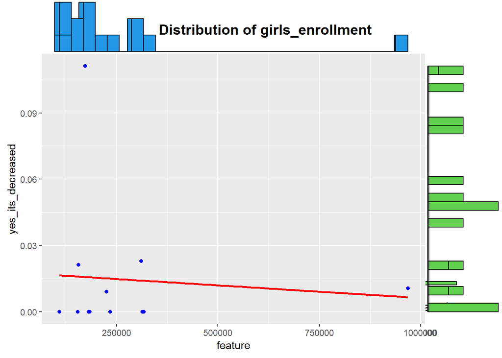

### How long does the water collection process take on a daily basis?

**Data Source**: Paired Household Surveys (Pre & Post)

**Value (Encoding if applied)**: “less than 1 hour” = 1; “1-2 hours” = 2; “2-3 hours” = 3; “3-4 hours” = 4; “greater than 4 hours” = 5

**Hypothesis Testing:**

- ${H_0}$ = No difference between pre and post scores assigned to water collection time
- ${H_1}$ = A significant difference between pre and post scores assigned to water collection time

```r
## Wilcoxon Signed Rank Test
# Scores
# paired_enc <- paired_enc %>% filter(if_all(c(water_collection_time_pre,
#                                             water_collection_time_post),
#                                            ~ !is.na(.)))
pre_scores <- paired_enc$water_collection_time_pre
post_scores <- paired_enc$water_collection_time_post


# Running the test
wilcox.test(pre_scores, post_scores, paired=TRUE)
```

```
##
##  Wilcoxon signed rank test with continuity correction
##
## data:  pre_scores and post_scores
## V = 3621, p-value = 0.004388
## alternative hypothesis: true location shift is not equal to 0
```

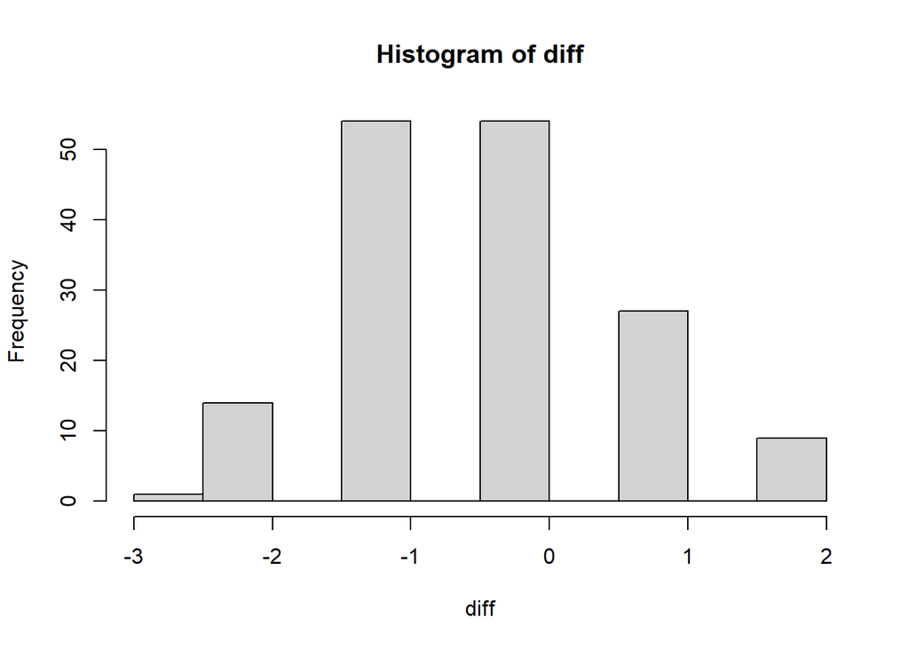

```r
# Visualize distribution of score differences
diff <- post_scores - pre_scores
hist(diff)
```

### How long does the cooking fuel collection process take on a daily basis?

**Data Source**: Paired Household Surveys (Pre & Post)

**Value (Encoding if applied)**: “No need to collect fuel” = 1; “less than 1 hour” = 2; “1-2 hours” =3; “3-5 hours” = 4; “greater than 4 hours” = 5

**Hypothesis Testing:**

- ${H_0}$ = No difference between pre and post scores assigned to cooking fuel collection time
- ${H_1}$ = A significant difference between pre and post scores assigned to cooking fuel collection time

```r
## Sign Test
# Calculating differences
pre_scores <- paired_enc$cooking_fuel_collection_time_pre
post_scores <- paired_enc$cooking_fuel_collection_time_post
diff <- post_scores - pre_scores

# Running the test
signtest(diff, m=0, conf.level=0.95, exact=FALSE)
```

```
##
##  Large Sample Approximation for the Sign Test
##
##  H0: The population median is =  0
##  HA: The population median is not equal to  0
##
##  B = 96
##
##  Significance Level = 0.05
##  The p-value is  0.0000000000410522667568692
##  There is enough evidence to conclude that the population median is different than 0 at a significance level of  0.05
##
##  The  95 % confidence interval is [ -1 ,  -1 ].
##
```

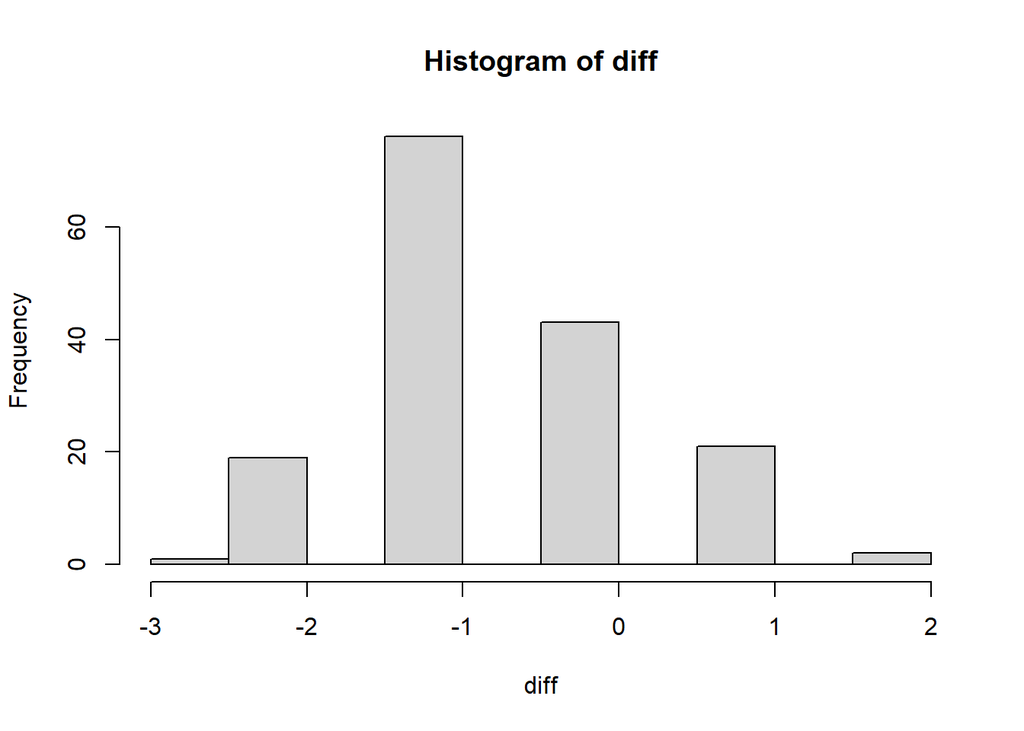

```r
# Visualize distribution of score differences
hist(diff)
```

### Are any household members business owners?

**Data Source**: Paired Household Surveys (Pre & Post)

**Value (Encoding if applied)**: “None” = 0; “Not None” = 1

**Hypothesis Testing:**

- ${H_0}$ = No difference between pre and post number of local female business owners
- ${H_1}$ = A significant difference between pre and post number of local female business owners

```r
## McNemar's  Test
# Cross tabulation of changes of women business ownership
cross_tab <- table(paired_enc$business_owners_female_pre,
                   paired_enc$business_owners_female_post)
cross_tab
```

```
##
##       0   1
##   0 112  31
##   1   6  13
```

```r
# Running the test
mcnemar.test(cross_tab)
```

```
##
##  McNemar's Chi-squared test with continuity correction
##
## data:  cross_tab
## McNemar's chi-squared = 15.568, df = 1, p-value = 0.00007961
```

```r
# Change
paired_enc$biz_female_change <- paired_enc$business_owners_female_pre - paired_enc$business_owners_female_post

# Breakdown by response type and Community
dep_var_mat <- rownames_to_column(as.data.frame.matrix(
                                      prop.table(table(
                                          paired_enc$community_post,
                                          paired_enc$biz_female_change),
                                         margin = 1)
                                                  )
                                      , var = "community")
community_data <- merge(x=projects, y=dep_var_mat, by="community")
reg_df <- community_data
names(reg_df)[7] <- "var_decrease"
names(reg_df)[8] <- "var_neutral"
names(reg_df)[9] <- "var_increase"
#
ind_vars <- reg_df[c(4:6)]

## Linear Regression t-Test
# Model with increase
reg_increase <- function(feature) {
  ## Fitting the model with reported increase
  # PV Size (kwH)
  lm <- lm(var_increase ~ feature, data=reg_df)
  print(summary(lm))

  # Visualizing
  scatter <- ggplot(data = reg_df,
                    aes(feature, var_increase)) +
                    geom_point(color='blue') +
                    geom_smooth(color='red', method = "lm", se = FALSE)
                    theme_classic()
  ggMarginal(scatter, type = "histogram",
             xparams = list(fill = 4),
             yparams = list(fill = 3))
}

reg_decrease <- function(feature) {
  ## Fitting the model with reported increase
  # PV Size (kwH)
  lm <- lm(var_decrease ~ feature, data=reg_df)
  print(summary(lm))

  # Visualizing
  scatter <- ggplot(data = reg_df,
                    aes(feature, var_decrease)) +
                    geom_point(color='blue') +
                    geom_smooth(color='red', method = "lm", se = FALSE)
                    theme_classic()
  ggMarginal(scatter, type = "histogram",
             xparams = list(fill = 4),
             yparams = list(fill = 3))
}

sapply(ind_vars, reg_increase)
```

```
##
## Call:
## lm(formula = var_increase ~ feature, data = reg_df)
##
## Residuals:
##      Min       1Q   Median       3Q      Max
## -0.10599 -0.10136 -0.07386  0.01783  0.39561
##
## Coefficients:
##               Estimate Std. Error t value Pr(>|t|)
## (Intercept)  0.1086039  0.0741024   1.466    0.193
## feature     -0.0002094  0.0003833  -0.546    0.605
##
## Residual standard error: 0.1845 on 6 degrees of freedom
## Multiple R-squared:  0.04738,    Adjusted R-squared:  -0.1114
## F-statistic: 0.2984 on 1 and 6 DF,  p-value: 0.6046
```

```
##
## Call:
## lm(formula = var_increase ~ feature, data = reg_df)
##
## Residuals:
##      Min       1Q   Median       3Q      Max
## -0.10449 -0.10233 -0.07505  0.01760  0.39518
##
## Coefficients:
##                Estimate  Std. Error t value Pr(>|t|)
## (Intercept)  0.11046635  0.07615988   1.450    0.197
## feature     -0.00004124  0.00007676  -0.537    0.610
##
## Residual standard error: 0.1846 on 6 degrees of freedom
## Multiple R-squared:  0.04589,    Adjusted R-squared:  -0.1131
## F-statistic: 0.2886 on 1 and 6 DF,  p-value: 0.6105
```

```
##
## Call:
## lm(formula = var_increase ~ feature, data = reg_df)
##
## Residuals:
##      Min       1Q   Median       3Q      Max
## -0.11900 -0.10122 -0.07109  0.02059  0.39145
##
## Coefficients:
##                  Estimate    Std. Error t value Pr(>|t|)
## (Intercept)  0.1346702156  0.1032702144   1.304    0.240
## feature     -0.0000001441  0.0000002550  -0.565    0.593
##
## Residual standard error: 0.1841 on 6 degrees of freedom
## Multiple R-squared:  0.05051,    Adjusted R-squared:  -0.1077
## F-statistic: 0.3192 on 1 and 6 DF,  p-value: 0.5926
```

```r
sapply(ind_vars, reg_decrease)
```

```
##
## Call:
## lm(formula = var_decrease ~ feature, data = reg_df)
##
## Residuals:
##      Min       1Q   Median       3Q      Max
## -0.13690 -0.13374 -0.03066  0.08309  0.29318
##
## Coefficients:
##               Estimate Std. Error t value Pr(>|t|)
## (Intercept)  0.1398741  0.0652998   2.142   0.0759 .
## feature     -0.0002383  0.0003378  -0.705   0.5070
## ---
## Signif. codes:  0 '***' 0.001 '**' 0.01 '*' 0.05 '.' 0.1 ' ' 1
##
## Residual standard error: 0.1625 on 6 degrees of freedom
## Multiple R-squared:  0.07659,    Adjusted R-squared:  -0.07731
## F-statistic: 0.4976 on 1 and 6 DF,  p-value: 0.507
```

```
##
## Call:
## lm(formula = var_decrease ~ feature, data = reg_df)
##
## Residuals:
##      Min       1Q   Median       3Q      Max
## -0.13611 -0.13391 -0.03099  0.08567  0.29186
##
## Coefficients:
##                Estimate  Std. Error t value Pr(>|t|)
## (Intercept)  0.14273495  0.06697888   2.131   0.0771 .
## feature     -0.00004837  0.00006751  -0.717   0.5006
## ---
## Signif. codes:  0 '***' 0.001 '**' 0.01 '*' 0.05 '.' 0.1 ' ' 1
##
## Residual standard error: 0.1623 on 6 degrees of freedom
## Multiple R-squared:  0.07883,    Adjusted R-squared:  -0.0747
## F-statistic: 0.5134 on 1 and 6 DF,  p-value: 0.5006
```

```
##
## Call:
## lm(formula = var_decrease ~ feature, data = reg_df)
##
## Residuals:
##      Min       1Q   Median       3Q      Max
## -0.13401 -0.12526 -0.05569  0.09409  0.30618
##
## Coefficients:
##                   Estimate     Std. Error t value Pr(>|t|)
## (Intercept)  0.14248566546  0.09397924180   1.516    0.180
## feature     -0.00000007789  0.00000023205  -0.336    0.749
##
## Residual standard error: 0.1676 on 6 degrees of freedom
## Multiple R-squared:  0.01843,    Adjusted R-squared:  -0.1452
## F-statistic: 0.1127 on 1 and 6 DF,  p-value: 0.7485
```

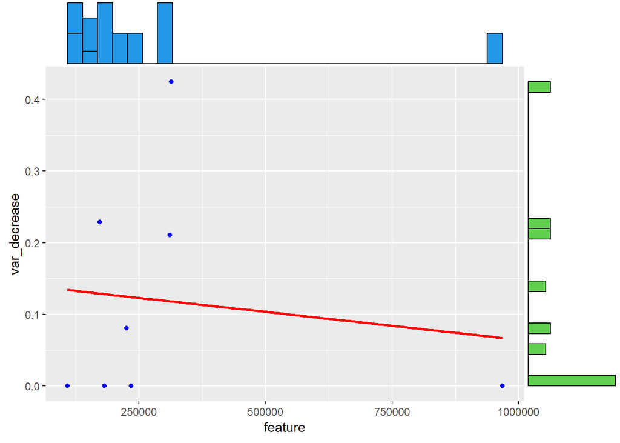

### If you answered yes to adding new workers, how many new employees are female?

**Data Source**: Commercial & Institution Post Survey

**Value (Encoding if applied)**: Any value

# 2- Productivity

### How many hours of light per day do you currently have at home?

**Data Source**: Paired Household Surveys (Pre & Post)

**Value (Encoding if applied)**: Any numeric value between 0 and 24

**Hypothesis Testing:**

- ${H_0}$ = No difference between pre and post light hours
- ${H_1}$ = A significant difference between pre and post light hours

```r
# Running the paired t-test
light_hours_pre <- paired_clean$light_hours_current_pre
light_hours_post <- paired_clean$light_hours_current_post
t.test(light_hours_pre, light_hours_post,
       paired = TRUE, alternative = "two.sided")
```

```
##
##  Paired t-test
##
## data:  light_hours_pre and light_hours_post
## t = 1.964, df = 150, p-value = 0.05138
## alternative hypothesis: true mean difference is not equal to 0
## 95 percent confidence interval:
##  -0.004250271  1.408223781
## sample estimates:
## mean difference
##       0.7019868
```

### Since connection to Renewvia mini-grid, have your hours of operation changed at all?

**Data Source**: C&I Post-Survey

**Value (Encoding if applied)**: “Yes, they have increased” = 1, “Yes, they have decreased” = -1, “No, it is pretty much the same” = 0

**Hypothesis Testing:**

- ${H_0}$ = No relationship between any independent variable (as described above) and increase in local businesses’ hours of operations
- ${H_1}$ = A relationship between any independent variable (as described above) and increase in local businesses’ hours of operations

```r
# Isolate the dependent variable
var <- ci_clean$operations_hours_change
work_hours <- var[var != ""]

tab1(work_hours,
     sort.group = "decreasing",
     cum.percent = TRUE)
```

```
## work_hours :
##                               Frequency Percent Cum. percent
## yes_they_have_increased             261    88.5         88.5
## no_it_is_pretty_much_the_same        29     9.8         98.3
## yes_they_have_decreased               5     1.7        100.0
##   Total                             295   100.0        100.0
```

```r
# Breakdown by response type and Community
dep_var_mat <- rownames_to_column(as.data.frame.matrix(
                                      prop.table(table(
                                          ci_clean$community,
                                          ci_clean$operations_hours_change),
                                         margin = 1)
                                                  )
                                      , var = "community")

community_data <- merge(x=projects, y=dep_var_mat, by="community")
reg_df <- community_data
# reg_df <- community_data %>% filter(community != "kalobeyei_settlement")

ind_vars <- reg_df[c(4:6)]

## Linear Regression t-Test with outlier: kalobeyei_settlement
# Model with increase
reg_increase <- function(feature) {
  ## Fitting the model with reported increase
  # PV Size (kwH)
  lm <- lm(yes_they_have_increased ~ feature, data=reg_df)
  print(summary(lm))

  # Visualizing
  scatter <- ggplot(data = reg_df,
                    aes(feature, yes_they_have_increased)) +
                    geom_point(color='blue') +
                    geom_smooth(color='red', method = "lm", se = FALSE)
                    theme_classic()
  ggMarginal(scatter, type = "histogram",
             xparams = list(fill = 4),
             yparams = list(fill = 3))
}

reg_decrease <- function(feature) {
  ## Fitting the model with reported increase
  # PV Size (kwH)
  lm <- lm(yes_they_have_decreased ~ feature, data=reg_df)
  print(summary(lm))

  # Visualizing
  scatter <- ggplot(data = reg_df,
                    aes(feature, yes_they_have_decreased)) +
                    geom_point(color='blue') +
                    geom_smooth(color='red', method = "lm", se = FALSE)
                    theme_classic()
  ggMarginal(scatter, type = "histogram",
             xparams = list(fill = 4),
             yparams = list(fill = 3))
}

sapply(ind_vars, reg_increase)
```

```
##
## Call:
## lm(formula = yes_they_have_increased ~ feature, data = reg_df)
##
## Residuals:
##     Min      1Q  Median      3Q     Max
## -0.7132 -0.2626  0.1970  0.2746  0.2852
##
## Coefficients:
##              Estimate Std. Error t value   Pr(>|t|)
## (Intercept) 0.7082693  0.0982034   7.212 0.00000448 ***
## feature     0.0005246  0.0007079   0.741      0.471
## ---
## Signif. codes:  0 '***' 0.001 '**' 0.01 '*' 0.05 '.' 0.1 ' ' 1
##
## Residual standard error: 0.3551 on 14 degrees of freedom
## Multiple R-squared:  0.03774,    Adjusted R-squared:  -0.03099
## F-statistic: 0.5491 on 1 and 14 DF,  p-value: 0.4709
```

```
##
## Call:
## lm(formula = yes_they_have_increased ~ feature, data = reg_df)
##
## Residuals:
##     Min      1Q  Median      3Q     Max
## -0.7246 -0.2789  0.1989  0.2738  0.2856
##
## Coefficients:
##               Estimate Std. Error t value   Pr(>|t|)
## (Intercept) 0.70931546 0.10457756   6.783 0.00000884 ***
## feature     0.00008029 0.00014435   0.556      0.587
## ---
## Signif. codes:  0 '***' 0.001 '**' 0.01 '*' 0.05 '.' 0.1 ' ' 1
##
## Residual standard error: 0.358 on 14 degrees of freedom
## Multiple R-squared:  0.02162,    Adjusted R-squared:  -0.04826
## F-statistic: 0.3094 on 1 and 14 DF,  p-value: 0.5868
```

```
##
## Call:
## lm(formula = yes_they_have_increased ~ feature, data = reg_df)
##
## Residuals:
##     Min      1Q  Median      3Q     Max
## -0.7103 -0.2866  0.1919  0.2755  0.3066
##
## Coefficients:
##                 Estimate   Std. Error t value Pr(>|t|)
## (Intercept) 0.6638823921 0.1581600581   4.198 0.000895 ***
## feature     0.0000002710 0.0000004682   0.579 0.571860
## ---
## Signif. codes:  0 '***' 0.001 '**' 0.01 '*' 0.05 '.' 0.1 ' ' 1
##
## Residual standard error: 0.3577 on 14 degrees of freedom
## Multiple R-squared:  0.02338,    Adjusted R-squared:  -0.04638
## F-statistic: 0.3351 on 1 and 14 DF,  p-value: 0.5719
```

```r
sapply(ind_vars, reg_decrease)
```

```
##
## Call:
## lm(formula = yes_they_have_decreased ~ feature, data = reg_df)
##
## Residuals:
##      Min       1Q   Median       3Q      Max
## -0.03793 -0.03755 -0.03695 -0.02761  0.29554
##
## Coefficients:
##                Estimate  Std. Error t value Pr(>|t|)
## (Intercept)  0.03832734  0.02535810   1.511    0.153
## feature     -0.00004271  0.00018279  -0.234    0.819
##
## Residual standard error: 0.09168 on 14 degrees of freedom
## Multiple R-squared:  0.003885,   Adjusted R-squared:  -0.06727
## F-statistic: 0.0546 on 1 and 14 DF,  p-value: 0.8186
```

```
##
## Call:
## lm(formula = yes_they_have_decreased ~ feature, data = reg_df)
##
## Residuals:
##      Min       1Q   Median       3Q      Max
## -0.03760 -0.03693 -0.03669 -0.02925  0.29647
##
## Coefficients:
##                 Estimate   Std. Error t value Pr(>|t|)
## (Intercept)  0.037968361  0.026809228   1.416    0.179
## feature     -0.000005807  0.000037006  -0.157    0.878
##
## Residual standard error: 0.09178 on 14 degrees of freedom
## Multiple R-squared:  0.001756,   Adjusted R-squared:  -0.06955
## F-statistic: 0.02462 on 1 and 14 DF,  p-value: 0.8776
```

```
##
## Call:
## lm(formula = yes_they_have_decreased ~ feature, data = reg_df)
##
## Residuals:
##      Min       1Q   Median       3Q      Max
## -0.03778 -0.03691 -0.03636 -0.03015  0.29647
##
## Coefficients:
##                   Estimate     Std. Error t value Pr(>|t|)
## (Intercept)  0.03905768629  0.04060381406   0.962    0.352
## feature     -0.00000001172  0.00000012020  -0.097    0.924
##
## Residual standard error: 0.09183 on 14 degrees of freedom
## Multiple R-squared:  0.0006785,  Adjusted R-squared:  -0.0707
## F-statistic: 0.009505 on 1 and 14 DF,  p-value: 0.9237
```

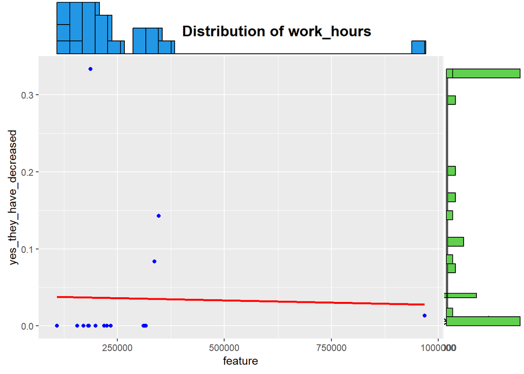

### Have you seen a change in overall school performance?

**Data Source**: C&I Post-Survey

**Value (Encoding if applied)**: “Yes, they have increased” = 1, “Yes, they have decreased” = -1, “No, it is pretty much the same” = 0

**Hypothesis Testing:**

- ${H_0}$ = No relationship between any independent variable (as described above) and school performance by schools
- ${H_1}$ = A relationship between any independent variable (as described above) and school performance by schools

```r
# Isolate the dependent variable
var <- ci_clean$school_performance
ci_school_performance <- var[var != ""]

tab1(ci_school_performance,
     sort.group = "decreasing",
     cum.percent = TRUE)
```

```
## ci_school_performance :
##                                           Frequency Percent Cum. percent
## no_there_has_not_been_a_noticeable_change        93      71           71
## yes_overall_school_performance_is_better         38      29          100
##   Total                                         131     100          100
```

```
##
## Call:
## lm(formula = yes_overall_school_performance_is_better ~ feature,
##     data = reg_df)
##
## Residuals:
##      Min       1Q   Median       3Q      Max
## -0.14527 -0.14423 -0.00476  0.08437  0.31810
##
## Coefficients:
##               Estimate Std. Error t value Pr(>|t|)
## (Intercept)  0.1462100  0.0406864   3.594  0.00294 **
## feature     -0.0001004  0.0002933  -0.342  0.73727
## ---
## Signif. codes:  0 '***' 0.001 '**' 0.01 '*' 0.05 '.' 0.1 ' ' 1
##
## Residual standard error: 0.1471 on 14 degrees of freedom
## Multiple R-squared:  0.008296,   Adjusted R-squared:  -0.06254
## F-statistic: 0.1171 on 1 and 14 DF,  p-value: 0.7373
```

```
##
## Call:
## lm(formula = yes_overall_school_performance_is_better ~ feature,
##     data = reg_df)
##
## Residuals:
##      Min       1Q   Median       3Q      Max
## -0.14823 -0.14391  0.00044  0.08380  0.31668
##
## Coefficients:
##                Estimate  Std. Error t value Pr(>|t|)
## (Intercept)  0.14984809  0.04286230   3.496  0.00356 **
## feature     -0.00002561  0.00005916  -0.433  0.67175
## ---
## Signif. codes:  0 '***' 0.001 '**' 0.01 '*' 0.05 '.' 0.1 ' ' 1
##
## Residual standard error: 0.1467 on 14 degrees of freedom
## Multiple R-squared:  0.0132, Adjusted R-squared:  -0.05728
## F-statistic: 0.1873 on 1 and 14 DF,  p-value: 0.6717
```

```
##
## Call:
## lm(formula = yes_overall_school_performance_is_better ~ feature,
##     data = reg_df)
##
## Residuals:
##      Min       1Q   Median       3Q      Max
## -0.14927 -0.14523 -0.00149  0.07778  0.31803
##
## Coefficients:
##                  Estimate    Std. Error t value Pr(>|t|)
## (Intercept)  0.1607610942  0.0649756556   2.474   0.0268 *
## feature     -0.0000000736  0.0000001923  -0.383   0.7077
## ---
## Signif. codes:  0 '***' 0.001 '**' 0.01 '*' 0.05 '.' 0.1 ' ' 1
##
## Residual standard error: 0.1469 on 14 degrees of freedom
## Multiple R-squared:  0.01035,    Adjusted R-squared:  -0.06034
## F-statistic: 0.1464 on 1 and 14 DF,  p-value: 0.7077
```

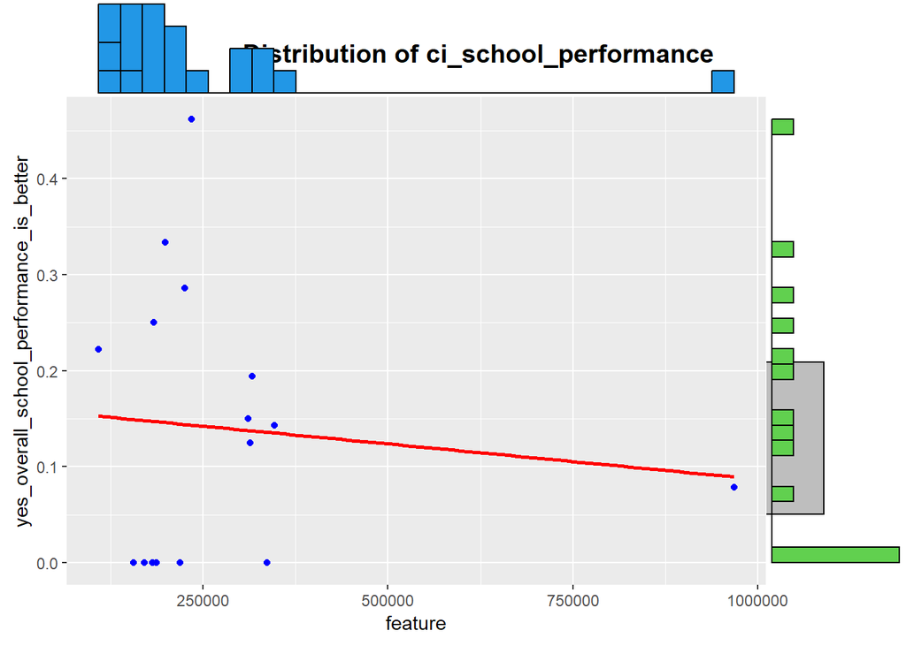

```r
# Breakdown by response type and Community
dep_var_mat <- rownames_to_column(as.data.frame.matrix(
                                      prop.table(table(
                                          ci_clean$community,
                                          ci_clean$school_performance),
                                         margin = 1)
                                                  )
                                      , var = "community")

community_data <- merge(x=projects, y=dep_var_mat, by="community")
reg_df <- community_data

## Linear Regression t-Test

reg <- function(feature) {
  ## Fitting the model with reported increase
  lm <- lm(yes_overall_school_performance_is_better ~ feature, data=reg_df)
  print(summary(lm))

  # Visualizing
  scatter <- ggplot(data = reg_df,
                    aes(feature, yes_overall_school_performance_is_better)) +
                    geom_point(color='blue') +
                    geom_smooth(color='red', method = "lm", se = FALSE)
                    theme_classic()
  ggMarginal(scatter, type = "histogram",
             xparams = list(fill = 4),
             yparams = list(fill = 3))
}

sapply(ind_vars, reg)
```

### Has school performance changed since connection to mini-grid?

**Data Source**: Household Post-Survey

**Value (Encoding if applied)**: “Yes, they have increased” = 1, “Yes, they have decreased” = -1, “No, it is pretty much the same” = 0

**Hypothesis Testing:**

- ${H_0}$ = No relationship between any independent variable (as described above) and school performance by households
- ${H_1}$ = A relationship between any independent variable (as described above) and school performance by households

```r
# Isolate the dependent variable
var <- post_hs$school_performance_change
hs_school_performance <- var[var != ""]

tab1(hs_school_performance,
     sort.group = "decreasing",
     cum.percent = TRUE)
```

```
## hs_school_performance :
##                       Frequency Percent Cum. percent
## yes_its_gotten_better       545    58.9         58.9
## no_its_the_same             376    40.6         99.6
## yes_its_gotten_worse          4     0.4        100.0
##   Total                     925   100.0        100.0
```

```
##
## Call:
## lm(formula = yes_its_gotten_better ~ feature, data = reg_df)
##
## Residuals:
##      Min       1Q   Median       3Q      Max
## -0.63261 -0.01711  0.03313  0.17552  0.28052
##
## Coefficients:
##               Estimate Std. Error t value  Pr(>|t|)
## (Intercept)  0.6517100  0.0874887   7.449 0.0000219 ***
## feature     -0.0010201  0.0005508  -1.852    0.0937 .
## ---
## Signif. codes:  0 '***' 0.001 '**' 0.01 '*' 0.05 '.' 0.1 ' ' 1
##
## Residual standard error: 0.2717 on 10 degrees of freedom
## Multiple R-squared:  0.2554, Adjusted R-squared:  0.181
## F-statistic:  3.43 on 1 and 10 DF,  p-value: 0.09372
```

```
##
## Call:
## lm(formula = yes_its_gotten_better ~ feature, data = reg_df)
##
## Residuals:
##      Min       1Q   Median       3Q      Max
## -0.60694  0.00343  0.03379  0.14235  0.26225
##
## Coefficients:
##               Estimate Std. Error t value Pr(>|t|)
## (Intercept)  0.6668910  0.0850228   7.844 0.000014 ***
## feature     -0.0002262  0.0001043  -2.168   0.0553 .
## ---
## Signif. codes:  0 '***' 0.001 '**' 0.01 '*' 0.05 '.' 0.1 ' ' 1
##
## Residual standard error: 0.2597 on 10 degrees of freedom
## Multiple R-squared:  0.3198, Adjusted R-squared:  0.2518
## F-statistic: 4.701 on 1 and 10 DF,  p-value: 0.05533
```

```
##
## Call:
## lm(formula = yes_its_gotten_better ~ feature, data = reg_df)
##
## Residuals:
##      Min       1Q   Median       3Q      Max
## -0.63501 -0.01081  0.04797  0.17751  0.26381
##
## Coefficients:
##                  Estimate    Std. Error t value Pr(>|t|)
## (Intercept)  0.7429168012  0.1313594929   5.656 0.000211 ***
## feature     -0.0000005880  0.0000003722  -1.580 0.145264
## ---
## Signif. codes:  0 '***' 0.001 '**' 0.01 '*' 0.05 '.' 0.1 ' ' 1
##
## Residual standard error: 0.2817 on 10 degrees of freedom
## Multiple R-squared:  0.1997, Adjusted R-squared:  0.1197
## F-statistic: 2.495 on 1 and 10 DF,  p-value: 0.1453
```

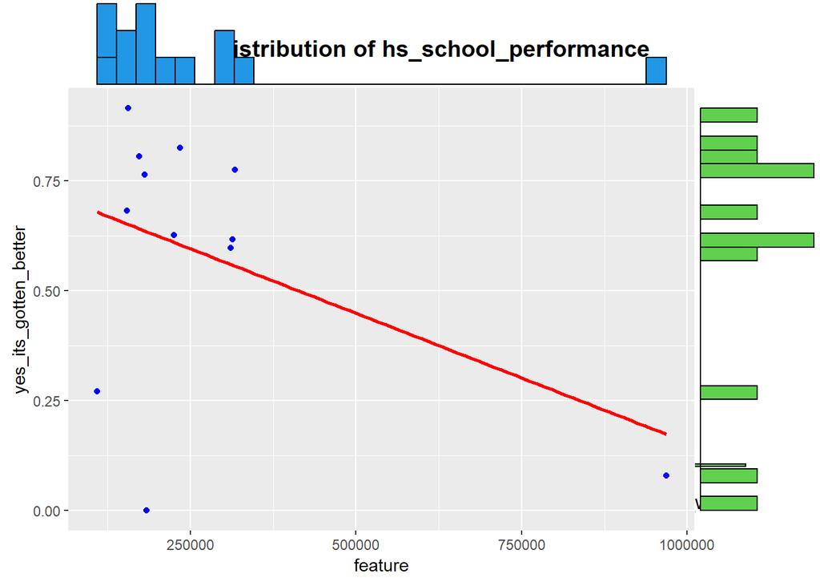

```r
# Breakdown by response type and Community
dep_var_mat <- rownames_to_column(as.data.frame.matrix(
                                      prop.table(table(
                                          post_hs$community,
                                          post_hs$school_performance_change),
                                         margin = 1)
                                                  )
                                      , var = "community")

community_data <- merge(x=projects, y=dep_var_mat, by="community")
reg_df <- community_data
# reg_df <- community_data %>% filter(community != "kalobeyei_settlement")
ind_vars <- reg_df[c(4:6)]

## Linear Regression t-Test with outlier: kalobeyei_settlement
# Model with increase
reg_increase <- function(feature) {
  ## Fitting the model with reported increase
  lm <- lm(yes_its_gotten_better ~ feature, data=reg_df)
  print(summary(lm))

  # Visualizing
  scatter <- ggplot(data = reg_df,
                    aes(feature, yes_its_gotten_better)) +
                    geom_point(color='blue') +
                    geom_smooth(color='red', method = "lm", se = FALSE)
                    theme_classic()
  ggMarginal(scatter, type = "histogram",
             xparams = list(fill = 4),
             yparams = list(fill = 3))
}

# reg_decrease <- function(feature) {
#   ## Fitting the model with reported increase
#   # PV Size (kwH)
#   lm <- lm(yes_its_gotten_worse ~ feature, data=reg_df)
#   print(summary(lm))
#
#   # Visualizing
#   scatter <- ggplot(data = reg_df,
#                     aes(feature, yes_its_gotten_worse)) +
#                     geom_point(color='blue') +
#                     geom_smooth(color='red', method = "lm", se = FALSE)
#                     theme_classic()
#   ggMarginal(scatter, type = "histogram",
#              xparams = list(fill = 4),
#              yparams = list(fill = 3))
# }

sapply(ind_vars, reg_increase)
```

```r
# sapply(ind_vars, reg_decrease)
```

# 3- Health

### For clinics or health services only: Since connection to Renewvia mini-grid, have your health service offerings changed in any of the following ways: (select all that apply).

**Data Source**: Commercial & Institution Post Survey

**Value (Encoding if applied)**: Any value

**Hypothesis Testing:**

- ${H_0}$ = No relationship between any independent variable (as described above) and number of new health services offered
- ${H_1}$ = A relationship between any independent variable (as described above) and number of new health services offered

```
##
## Call:
## lm(formula = new_health_services ~ feature, data = reg_df)
##
## Residuals:
##     Min      1Q  Median      3Q     Max
## -17.220  -5.399  -2.324   2.515  40.658
##
## Coefficients:
##             Estimate Std. Error t value    Pr(>|t|)
## (Intercept) -1.57439    3.52674  -0.446       0.662
## feature      0.29403    0.02542  11.566 0.000000015 ***
## ---
## Signif. codes:  0 '***' 0.001 '**' 0.01 '*' 0.05 '.' 0.1 ' ' 1
##
## Residual standard error: 12.75 on 14 degrees of freedom
## Multiple R-squared:  0.9053, Adjusted R-squared:  0.8985
## F-statistic: 133.8 on 1 and 14 DF,  p-value: 0.00000001499
```

```
##
## Call:
## lm(formula = new_health_services ~ feature, data = reg_df)
##
## Residuals:
##     Min      1Q  Median      3Q     Max
## -16.419  -8.351  -4.535   5.169  43.075
##
## Coefficients:
##              Estimate Std. Error t value     Pr(>|t|)
## (Intercept) -6.116202   4.157444  -1.471        0.163
## feature      0.058692   0.005739  10.227 0.0000000706 ***
## ---
## Signif. codes:  0 '***' 0.001 '**' 0.01 '*' 0.05 '.' 0.1 ' ' 1
##
## Residual standard error: 14.23 on 14 degrees of freedom
## Multiple R-squared:  0.882,  Adjusted R-squared:  0.8735
## F-statistic: 104.6 on 1 and 14 DF,  p-value: 0.00000007065
```

```
##
## Call:
## lm(formula = new_health_services ~ feature, data = reg_df)
##
## Residuals:
##     Min      1Q  Median      3Q     Max
## -26.893 -17.650   1.131   7.617  46.365
##
## Coefficients:
##                 Estimate   Std. Error t value   Pr(>|t|)
## (Intercept) -33.49178919   8.92407078  -3.753    0.00214 **
## feature       0.00017718   0.00002642   6.707 0.00000999 ***
## ---
## Signif. codes:  0 '***' 0.001 '**' 0.01 '*' 0.05 '.' 0.1 ' ' 1
##
## Residual standard error: 20.18 on 14 degrees of freedom
## Multiple R-squared:  0.7626, Adjusted R-squared:  0.7457
## F-statistic: 44.98 on 1 and 14 DF,  p-value: 0.000009994
```

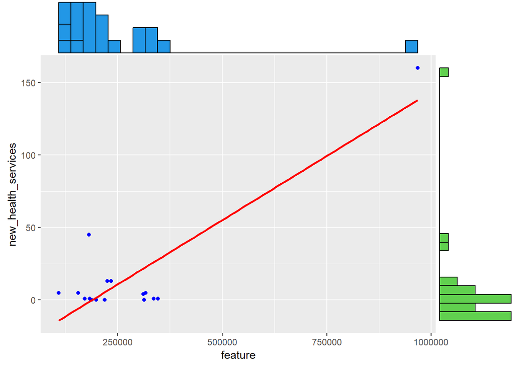

```r
# Breakdown by response type and Community
dep_var_mat <- ci_clean %>%
                  group_by(community) %>%
                  summarise(new_health_services = sum(
                    health_offering_change_count))

community_data <- merge(x=projects, y=dep_var_mat, by="community")
reg_df <- community_data %>% replace(is.na(.), 0)

ind_vars <- reg_df[c(4:6)]

## Linear Regression t-Test

reg <- function(feature) {
  ## Fitting the model with reported increase
  lm <- lm(new_health_services ~ feature, data=reg_df)
  print(summary(lm))

  # Visualizing
  scatter <- ggplot(data = reg_df,
                    aes(feature, new_health_services)) +
                    geom_point(color='blue') +
                    geom_smooth(color='red', method = "lm", se = FALSE)
                    theme_classic()
  ggMarginal(scatter, type = "histogram",
             xparams = list(fill = 4),
             yparams = list(fill = 3))
}

sapply(ind_vars, reg)
```

### Does your Health Center / Clinic have access to refrigeration?

**Data Source**: Paired Household Surveys (Pre & Post)

**Value (Encoding if applied)**: “yes” = 1; “no” = 0

**Hypothesis Testing:**

- ${H_0}$ = No relationship between any independent variable (as described above) and reported clinic access to refrigeration
- ${H_1}$ = A relationship between any independent variable (as described above) and reported clinic access to refrigeration

```r
## McNemar's  Test
# Cross tabulation of changes of women business ownership
var_pre <- paired_enc$clinic_refrigeration_access_pre
var_post <- paired_enc$clinic_refrigeration_access_post
cross_tab <- table(var_pre,var_post)
cross_tab
```

```
##        var_post
## var_pre  0  1
##       0  3 55
##       1 21 67
```

```r
# Running the test
mcnemar.test(cross_tab)
```

```
##
##  McNemar's Chi-squared test with continuity correction
##
## data:  cross_tab
## McNemar's chi-squared = 14.329, df = 1, p-value = 0.0001535
```

```r
# Change
paired_enc$clinic_electricity_change <- var_pre - var_post

# Breakdown by response type and Community
dep_var_mat <- rownames_to_column(as.data.frame.matrix(
                                      prop.table(table(
                                          paired_enc$community_post,
                                          paired_enc$clinic_electricity_change),
                                         margin = 1)
                                                  )
                                      , var = "community")
community_data <- merge(x=projects, y=dep_var_mat, by="community")
reg_df <- community_data
names(reg_df)[7] <- "var_decrease"
names(reg_df)[8] <- "var_neutral"
names(reg_df)[9] <- "var_increase"
#
ind_vars <- reg_df[c(4:6)]

## Linear Regression t-Test
# Model with increase
reg_increase <- function(feature) {
  ## Fitting the model with reported increase
  # PV Size (kwH)
  lm <- lm(var_increase ~ feature, data=reg_df)
  print(summary(lm))

  # Visualizing
  scatter <- ggplot(data = reg_df,
                    aes(feature, var_increase)) +
                    geom_point(color='blue') +
                    geom_smooth(color='red', method = "lm", se = FALSE)
                    theme_classic()
  ggMarginal(scatter, type = "histogram",
             xparams = list(fill = 4),
             yparams = list(fill = 3))
}

reg_decrease <- function(feature) {
  ## Fitting the model with reported increase
  # PV Size (kwH)
  lm <- lm(var_decrease ~ feature, data=reg_df)
  print(summary(lm))

  # Visualizing
  scatter <- ggplot(data = reg_df,
                    aes(feature, var_decrease)) +
                    geom_point(color='blue') +
                    geom_smooth(color='red', method = "lm", se = FALSE)
                    theme_classic()
  ggMarginal(scatter, type = "histogram",
             xparams = list(fill = 4),
             yparams = list(fill = 3))
}

sapply(ind_vars, reg_increase)
```

```
##
## Call:
## lm(formula = var_increase ~ feature, data = reg_df)
##
## Residuals:
##          1          2          4          5          6
## -0.0142469 -0.0004704 -0.2358661  0.4864028 -0.2358194
##
## Coefficients:
##               Estimate Std. Error t value Pr(>|t|)
## (Intercept)  0.2530833  0.1827757   1.385    0.260
## feature     -0.0004666  0.0007491  -0.623    0.577
##
## Residual standard error: 0.3406 on 3 degrees of freedom
##   (3 observations deleted due to missingness)
## Multiple R-squared:  0.1145, Adjusted R-squared:  -0.1806
## F-statistic: 0.388 on 1 and 3 DF,  p-value: 0.5775
```

```
##
## Call:
## lm(formula = var_increase ~ feature, data = reg_df)
##
## Residuals:
##        1        2        4        5        6
## -0.01089 -0.02451 -0.23294  0.49996 -0.23163
##
## Coefficients:
##                Estimate  Std. Error t value Pr(>|t|)
## (Intercept)  0.24907730  0.18960603   1.314    0.280
## feature     -0.00008151  0.00015183  -0.537    0.629
##
## Residual standard error: 0.3457 on 3 degrees of freedom
##   (3 observations deleted due to missingness)
## Multiple R-squared:  0.08765,    Adjusted R-squared:  -0.2165
## F-statistic: 0.2882 on 1 and 3 DF,  p-value: 0.6286
```

```
##
## Call:
## lm(formula = var_increase ~ feature, data = reg_df)
##
## Residuals:
##        1        2        4        5        6
## -0.02303 -0.03508 -0.23715  0.50842 -0.21316
##
## Coefficients:
##                  Estimate    Std. Error t value Pr(>|t|)
## (Intercept)  0.2985132120  0.2638960028   1.131    0.340
## feature     -0.0000002722  0.0000005359  -0.508    0.647
##
## Residual standard error: 0.3473 on 3 degrees of freedom
##   (3 observations deleted due to missingness)
## Multiple R-squared:  0.07918,    Adjusted R-squared:  -0.2278
## F-statistic: 0.258 on 1 and 3 DF,  p-value: 0.6465
```

```r
sapply(ind_vars, reg_decrease)
```

```
##
## Call:
## lm(formula = var_decrease ~ feature, data = reg_df)
##
## Residuals:
##         1         2         4         5         6
## -0.228540 -0.006662  0.679465 -0.222132 -0.222132
##
## Coefficients:
##               Estimate Std. Error t value Pr(>|t|)
## (Intercept)  0.2379375  0.2424974   0.981    0.399
## feature     -0.0004272  0.0009938  -0.430    0.696
##
## Residual standard error: 0.4519 on 3 degrees of freedom
##   (3 observations deleted due to missingness)
## Multiple R-squared:  0.05801,    Adjusted R-squared:  -0.256
## F-statistic: 0.1848 on 1 and 3 DF,  p-value: 0.6963
```

```
##
## Call:
## lm(formula = var_decrease ~ feature, data = reg_df)
##
## Residuals:
##        1        2        4        5        6
## -0.23552  0.00513  0.67342 -0.21627 -0.22676
##
## Coefficients:
##                Estimate  Std. Error t value Pr(>|t|)
## (Intercept)  0.24629033  0.24672227   0.998    0.392
## feature     -0.00009126  0.00019757  -0.462    0.676
##
## Residual standard error: 0.4499 on 3 degrees of freedom
##   (3 observations deleted due to missingness)
## Multiple R-squared:  0.0664, Adjusted R-squared:  -0.2448
## F-statistic: 0.2134 on 1 and 3 DF,  p-value: 0.6756
```

```
##
## Call:
## lm(formula = var_decrease ~ feature, data = reg_df)
##
## Residuals:
##        1        2        4        5        6
## -0.26398  0.03081  0.65733 -0.21252 -0.21164
##
## Coefficients:
##                  Estimate    Std. Error t value Pr(>|t|)
## (Intercept)  0.3278478368  0.3377004276   0.971    0.403
## feature     -0.0000003706  0.0000006858  -0.540    0.626
##
## Residual standard error: 0.4445 on 3 degrees of freedom
##   (3 observations deleted due to missingness)
## Multiple R-squared:  0.0887, Adjusted R-squared:  -0.2151
## F-statistic: 0.292 on 1 and 3 DF,  p-value: 0.6265
```

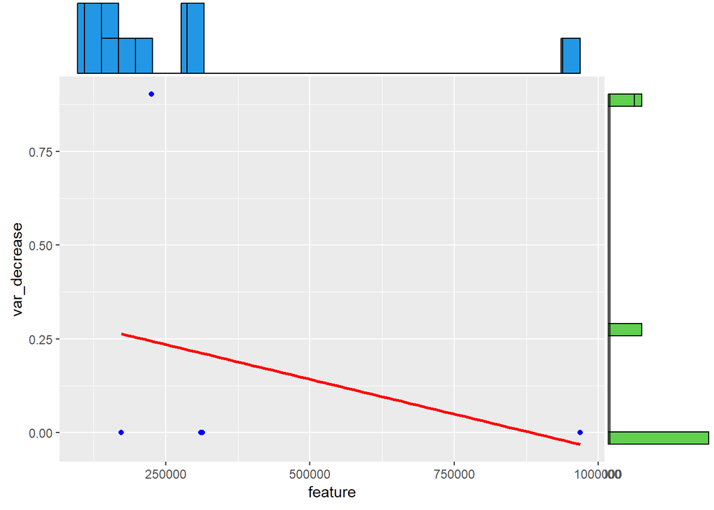

### Do you feel that you have better access to health services because of connection to mini-grid?

**Data Source**: Household Post-Survey

**Value (Encoding if applied)**: “yes” = 1; “no” = 0

**Hypothesis Testing:**

- ${H_0}$ = No relationship between any independent variable (as described above) and access to better healthcare
- ${H_1}$ = A relationship between any independent variable (as described above) and access to better healthcare

```
##
## Call:
## lm(formula = yes ~ feature, data = reg_df)
##
## Residuals:
##      Min       1Q   Median       3Q      Max
## -0.29094 -0.19689  0.06788  0.20180  0.20584
##
## Coefficients:
##              Estimate Std. Error t value Pr(>|t|)
## (Intercept) 0.7822796  0.0959227   8.155 0.000183 ***
## feature     0.0004305  0.0004962   0.868 0.418922
## ---
## Signif. codes:  0 '***' 0.001 '**' 0.01 '*' 0.05 '.' 0.1 ' ' 1
##
## Residual standard error: 0.2388 on 6 degrees of freedom
## Multiple R-squared:  0.1115, Adjusted R-squared:  -0.0366
## F-statistic: 0.7528 on 1 and 6 DF,  p-value: 0.4189
```

```
##
## Call:
## lm(formula = yes ~ feature, data = reg_df)
##
## Residuals:
##      Min       1Q   Median       3Q      Max
## -0.29266 -0.20479  0.07603  0.20217  0.20336
##
## Coefficients:
##               Estimate Std. Error t value Pr(>|t|)
## (Intercept) 0.78112385 0.09941493   7.857 0.000225 ***
## feature     0.00007955 0.00010020   0.794 0.457482
## ---
## Signif. codes:  0 '***' 0.001 '**' 0.01 '*' 0.05 '.' 0.1 ' ' 1
##
## Residual standard error: 0.241 on 6 degrees of freedom
## Multiple R-squared:  0.09507,    Adjusted R-squared:  -0.05576
## F-statistic: 0.6303 on 1 and 6 DF,  p-value: 0.4575
```

```
##
## Call:
## lm(formula = yes ~ feature, data = reg_df)
##
## Residuals:
##      Min       1Q   Median       3Q      Max
## -0.27624 -0.20470  0.06203  0.18524  0.20865
##
## Coefficients:
##                 Estimate   Std. Error t value Pr(>|t|)
## (Intercept) 0.7141390947 0.1302781678   5.482  0.00154 **
## feature     0.0000003425 0.0000003217   1.065  0.32799
## ---
## Signif. codes:  0 '***' 0.001 '**' 0.01 '*' 0.05 '.' 0.1 ' ' 1
##
## Residual standard error: 0.2323 on 6 degrees of freedom
## Multiple R-squared:  0.1589, Adjusted R-squared:  0.01871
## F-statistic: 1.134 on 1 and 6 DF,  p-value: 0.328
```

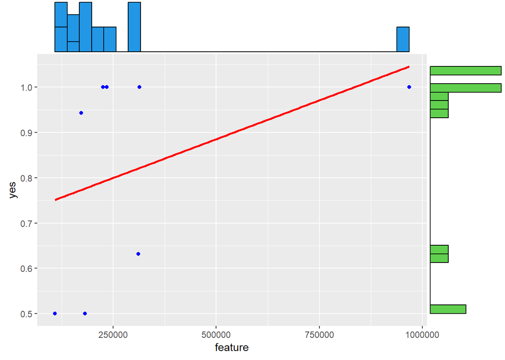

```r
# Breakdown by response type and Community
dep_var_mat <- rownames_to_column(as.data.frame.matrix(
                                      prop.table(table(
                                          paired_clean$community_post,
                                          paired_clean$better_access_health_minigrid),
                                         margin = 1)
                                                  )
                                      , var = "community")
community_data <- merge(x=projects, y=dep_var_mat, by="community")
reg_df <- community_data %>% replace(is.na(.), 0)

ind_vars <- reg_df[c(4:6)]

## Linear Regression t-Test

reg <- function(feature) {
  ## Fitting the model with reported increase
  lm <- lm(yes ~ feature, data=reg_df)
  print(summary(lm))

  # Visualizing
  scatter <- ggplot(data = reg_df,
                    aes(feature, yes)) +
                    geom_point(color='blue') +
                    geom_smooth(color='red', method = "lm", se = FALSE)
                    theme_classic()
  ggMarginal(scatter, type = "histogram",
             xparams = list(fill = 4),
             yparams = list(fill = 3))
}

sapply(ind_vars, reg)
```

### Do you have a source for clean drinking water?

**Data Source**: Paired Household Surveys (Pre & Post)

**Value (Encoding if applied)**: “yes” = 1; “no” = 0

**Hypothesis Testing:**

- ${H_0}$ = No relationship between any independent variable (as described above) and access to clean water
- ${H_1}$ = A relationship between any independent variable (as described above) and access to clean water

```r
## McNemar's  Test
# Cross tabulation of changes of women business ownership
var_pre <- paired_enc$clean_drinking_water_pre
var_post <- paired_enc$clean_drinking_water_post
cross_tab <- table(var_pre,var_post)
cross_tab
```

```
##        var_post
## var_pre  0  1
##       0 22 53
##       1 16 68
```

```r
# Running the test
mcnemar.test(cross_tab)
```

```
##
##  McNemar's Chi-squared test with continuity correction
##
## data:  cross_tab
## McNemar's chi-squared = 18.783, df = 1, p-value = 0.00001465
```

```r
# Change
paired_enc$clean_water_change <- var_pre - var_post

# Breakdown by response type and Community
dep_var_mat <- rownames_to_column(as.data.frame.matrix(
                                      prop.table(table(
                                          paired_enc$community_post,
                                          paired_enc$clean_water_change),
                                         margin = 1)
                                                  )
                                      , var = "community")
community_data <- merge(x=projects, y=dep_var_mat, by="community")
reg_df <- community_data
names(reg_df)[7] <- "var_decrease"
names(reg_df)[8] <- "var_neutral"
names(reg_df)[9] <- "var_increase"
#
ind_vars <- reg_df[c(4:6)]

## Linear Regression t-Test
# Model with increase
reg_increase <- function(feature) {
  ## Fitting the model with reported increase
  # PV Size (kwH)
  lm <- lm(var_increase ~ feature, data=reg_df)
  print(summary(lm))

  # Visualizing
  scatter <- ggplot(data = reg_df,
                    aes(feature, var_increase)) +
                    geom_point(color='blue') +
                    geom_smooth(color='red', method = "lm", se = FALSE)
                    theme_classic()
  ggMarginal(scatter, type = "histogram",
             xparams = list(fill = 4),
             yparams = list(fill = 3))
}

reg_decrease <- function(feature) {
  ## Fitting the model with reported increase
  # PV Size (kwH)
  lm <- lm(var_decrease ~ feature, data=reg_df)
  print(summary(lm))

  # Visualizing
  scatter <- ggplot(data = reg_df,
                    aes(feature, var_decrease)) +
                    geom_point(color='blue') +
                    geom_smooth(color='red', method = "lm", se = FALSE)
                    theme_classic()
  ggMarginal(scatter, type = "histogram",
             xparams = list(fill = 4),
             yparams = list(fill = 3))
}

sapply(ind_vars, reg_increase)
```

```
##
## Call:
## lm(formula = var_increase ~ feature, data = reg_df)
##
## Residuals:
##      Min       1Q   Median       3Q      Max
## -0.13254 -0.12738 -0.09851  0.05499  0.37131
##
## Coefficients:
##               Estimate Std. Error t value Pr(>|t|)
## (Intercept)  0.1357270  0.0827681   1.640    0.152
## feature     -0.0002551  0.0004281  -0.596    0.573
##
## Residual standard error: 0.206 on 6 degrees of freedom
## Multiple R-squared:  0.05589,    Adjusted R-squared:  -0.1015
## F-statistic: 0.3552 on 1 and 6 DF,  p-value: 0.573
```

```
##
## Call:
## lm(formula = var_increase ~ feature, data = reg_df)
##
## Residuals:
##      Min       1Q   Median       3Q      Max
## -0.13193 -0.12943 -0.09710  0.05648  0.37111
##
## Coefficients:
##                Estimate  Std. Error t value Pr(>|t|)
## (Intercept)  0.13911205  0.08486265   1.639    0.152
## feature     -0.00005243  0.00008553  -0.613    0.562
##
## Residual standard error: 0.2057 on 6 degrees of freedom
## Multiple R-squared:  0.05893,    Adjusted R-squared:  -0.09792
## F-statistic: 0.3757 on 1 and 6 DF,  p-value: 0.5624
```

```
##
## Call:
## lm(formula = var_increase ~ feature, data = reg_df)
##
## Residuals:
##      Min       1Q   Median       3Q      Max
## -0.14733 -0.12933 -0.08486  0.05086  0.37408
##
## Coefficients:
##                  Estimate    Std. Error t value Pr(>|t|)
## (Intercept)  0.1658567791  0.1155235217   1.436    0.201
## feature     -0.0000001704  0.0000002852  -0.597    0.572
##
## Residual standard error: 0.206 on 6 degrees of freedom
## Multiple R-squared:  0.05611,    Adjusted R-squared:  -0.1012
## F-statistic: 0.3567 on 1 and 6 DF,  p-value: 0.5722
```

```r
sapply(ind_vars, reg_decrease)
```

```
##
## Call:
## lm(formula = var_decrease ~ feature, data = reg_df)
##
## Residuals:
##     Min      1Q  Median      3Q     Max
## -0.3106 -0.3103 -0.1216  0.1880  0.6900
##
## Coefficients:
##               Estimate Std. Error t value Pr(>|t|)
## (Intercept) 0.30970057 0.16154802   1.917    0.104
## feature     0.00002533 0.00083560   0.030    0.977
##
## Residual standard error: 0.4021 on 6 degrees of freedom
## Multiple R-squared:  0.0001532,  Adjusted R-squared:  -0.1665
## F-statistic: 0.0009191 on 1 and 6 DF,  p-value: 0.9768
```

```
##
## Call:
## lm(formula = var_decrease ~ feature, data = reg_df)
##
## Residuals:
##     Min      1Q  Median      3Q     Max
## -0.3084 -0.3076 -0.1281  0.1893  0.6925
##
## Coefficients:
##               Estimate Std. Error t value Pr(>|t|)
## (Intercept) 0.30577152 0.16584218   1.844    0.115
## feature     0.00001223 0.00016715   0.073    0.944
##
## Residual standard error: 0.402 on 6 degrees of freedom
## Multiple R-squared:  0.0008916,  Adjusted R-squared:  -0.1656
## F-statistic: 0.005355 on 1 and 6 DF,  p-value: 0.944
```

```
##
## Call:
## lm(formula = var_decrease ~ feature, data = reg_df)
##
## Residuals:
##      Min       1Q   Median       3Q      Max
## -0.32634 -0.31424 -0.08927  0.18398  0.66585
##
## Coefficients:
##                  Estimate    Std. Error t value Pr(>|t|)
## (Intercept)  0.3458514470  0.2248214630   1.538    0.175
## feature     -0.0000001076  0.0000005551  -0.194    0.853
##
## Residual standard error: 0.4009 on 6 degrees of freedom
## Multiple R-squared:  0.006222,   Adjusted R-squared:  -0.1594
## F-statistic: 0.03757 on 1 and 6 DF,  p-value: 0.8527
```

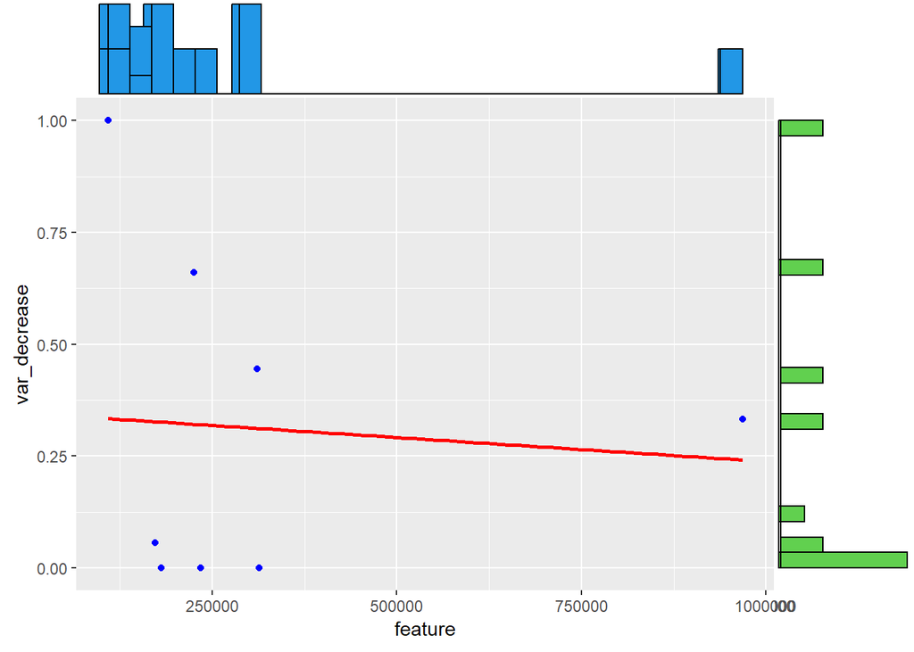

### Since connection to Renewvia mini-grid, has your access to clean drinking water changed at all?

**Data Source**: C&I Post Survey

**Value (Encoding if applied)**: “Yes, it’s decreased” = -1; “No, it’s the same” = 0; “Yes, it’s increased” = 1

**Hypothesis Testing:**

- ${H_0}$ = No relationship between any independent variable (as described above) and increase in access to clean drinking water for C&I
- ${H_1}$ = A relationship between any independent variable (as described above) and increase in access to clean drinking water for C&I

```r
# Isolate the dependent variable
var <- ci_clean$clean_drinking_water_access
hs_school_performance <- var[var != ""]

tab1(hs_school_performance,
     sort.group = "decreasing",
     cum.percent = TRUE)
```

```
## hs_school_performance :
##                               Frequency Percent Cum. percent
## no_it_is_pretty_much_the_same       212    71.9         71.9
## yes_it_has_increased                 82    27.8         99.7
## yes_it_has_decreased                  1     0.3        100.0
##   Total                             295   100.0        100.0
```

```
##
## Call:
## lm(formula = yes_it_has_increased ~ feature, data = reg_df)
##
## Residuals:
##     Min      1Q  Median      3Q     Max
## -0.3134 -0.3126 -0.2584  0.2187  0.6891
##
## Coefficients:
##               Estimate Std. Error t value Pr(>|t|)
## (Intercept)  0.3141741  0.1220502   2.574   0.0221 *
## feature     -0.0000872  0.0008798  -0.099   0.9225
## ---
## Signif. codes:  0 '***' 0.001 '**' 0.01 '*' 0.05 '.' 0.1 ' ' 1
##
## Residual standard error: 0.4413 on 14 degrees of freedom
## Multiple R-squared:  0.0007012,  Adjusted R-squared:  -0.07068
## F-statistic: 0.009824 on 1 and 14 DF,  p-value: 0.9225
```

```
##
## Call:
## lm(formula = yes_it_has_increased ~ feature, data = reg_df)
##
## Residuals:
##     Min      1Q  Median      3Q     Max
## -0.3177 -0.3149 -0.2649  0.2162  0.6893
##
## Coefficients:
##                Estimate  Std. Error t value Pr(>|t|)
## (Intercept)  0.32326684  0.12873117   2.511   0.0249 *
## feature     -0.00003808  0.00017769  -0.214   0.8334
## ---
## Signif. codes:  0 '***' 0.001 '**' 0.01 '*' 0.05 '.' 0.1 ' ' 1
##
## Residual standard error: 0.4407 on 14 degrees of freedom
## Multiple R-squared:  0.00327,    Adjusted R-squared:  -0.06793
## F-statistic: 0.04592 on 1 and 14 DF,  p-value: 0.8334
```

```
##
## Call:
## lm(formula = yes_it_has_increased ~ feature, data = reg_df)
##
## Residuals:
##     Min      1Q  Median      3Q     Max
## -0.3100 -0.3094 -0.2567  0.2217  0.6912
##
## Coefficients:
##                    Estimate      Std. Error t value Pr(>|t|)
## (Intercept)  0.310615888429  0.195182812119   1.591    0.134
## feature     -0.000000005802  0.000000577789  -0.010    0.992
##
## Residual standard error: 0.4414 on 14 degrees of freedom
## Multiple R-squared:  7.204e-06,  Adjusted R-squared:  -0.07142
## F-statistic: 0.0001009 on 1 and 14 DF,  p-value: 0.9921
```

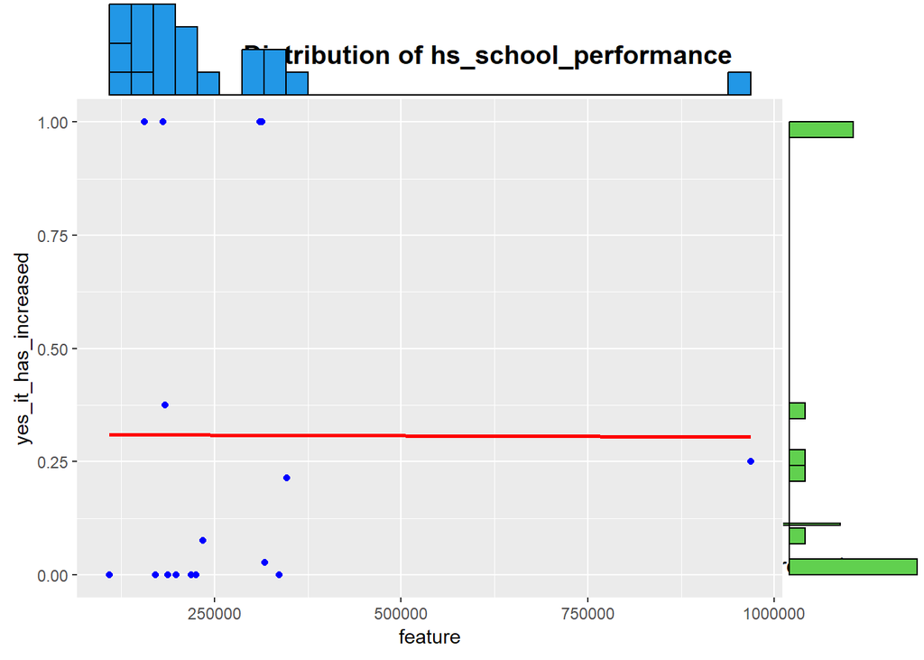

```r
# Breakdown by response type and Community
dep_var_mat <- rownames_to_column(as.data.frame.matrix(
                                      prop.table(table(
                                          ci_clean$community,
                                          ci_clean$clean_drinking_water_access),
                                         margin = 1)
                                                  )
                                      , var = "community")

community_data <- merge(x=projects, y=dep_var_mat, by="community")
reg_df <- community_data
# reg_df <- community_data %>% filter(community != "kalobeyei_settlement")
ind_vars <- reg_df[c(4:6)]

## Linear Regression t-Test with outlier: kalobeyei_settlement
# Model with increase
reg_increase <- function(feature) {
  ## Fitting the model with reported increase
  lm <- lm(yes_it_has_increased ~ feature, data=reg_df)
  print(summary(lm))

  # Visualizing
  scatter <- ggplot(data = reg_df,
                    aes(feature, yes_it_has_increased)) +
                    geom_point(color='blue') +
                    geom_smooth(color='red', method = "lm", se = FALSE)
                    theme_classic()
  ggMarginal(scatter, type = "histogram",
             xparams = list(fill = 4),
             yparams = list(fill = 3))
}
sapply(ind_vars, reg_increase)
```

```r
# sapply(ind_vars, reg_decrease)
```

### How many kerosene lamps do you currently use in your household?

**Data Source**: Paired Household Surveys (Pre & Post)

**Value (Encoding if applied)**: Any numeric value

**Hypothesis Testing:**

- ${H_0}$ = No difference between pre and post number of kerosene lamps used
- ${H_1}$ = A significant difference between pre and post number of kerosene lamps used

```r
# Running the paired t-test
kerosene_pre <- paired_clean$kerosene_lamps_count_pre
kerosene_post <- paired_clean$kerosene_lamps_count_post
t.test(kerosene_pre, kerosene_post,
       paired = TRUE, alternative = "two.sided")
```

```
##
##  Paired t-test
##
## data:  kerosene_pre and kerosene_post
## t = 0.04172, df = 161, p-value = 0.9668
## alternative hypothesis: true mean difference is not equal to 0
## 95 percent confidence interval:
##  -0.2860204  0.2983661
## sample estimates:
## mean difference
##      0.00617284
```

### Has the number of kerosene lamps in your household changed since connection to mini-grid

**Data Source**: Household Post Survey

**Value (Encoding if applied)**: “Yes, it’s decreased” = -1; “No, it’s the same” = 0; “Yes, it’s increased” = 1

**Hypothesis Testing:**

- ${H_0}$ = No relationship between any independent variable (as described above) and decrease in kerosene lamps usage
- ${H_1}$ = A relationship between any independent variable (as described above) and decrease in kerosene lamps usage

```r
# Isolate the dependent variable
var <- post_hs$kerosene_lamp_usage_change
kerosene_usage <- var[var != ""]

tab1(kerosene_usage,
     sort.group = "decreasing", cum.percent = TRUE)
```

```
## kerosene_usage :
##                   Frequency Percent Cum. percent
## no_its_the_same         491    46.3         46.3
## yes_its_decreased       444    41.8         88.1
## yes_its_increased       126    11.9        100.0
##   Total                1061   100.0        100.0
```

```r
# Breakdown by response type and Community
dep_var_mat <- rownames_to_column(
  as.data.frame.matrix(prop.table(table(post_hs$community,
                                   post_hs$kerosene_lamp_usage_change),
                                         margin = 1)
                                                  )
                                      , var = "community")
community_data <- merge(x=projects,
                                    y=dep_var_mat, by="community")
reg_df <- community_data
# reg_df <- community_data %>% filter(community != "kalobeyei_settlement")

ind_vars <- reg_df[c(4:6)]

## Linear Regression t-Test
# Model with increase
reg_increase <- function(feature) {
  ## Fitting the model with reported increase
  # PV Size (kwH)
  lm <- lm(yes_its_increased ~ feature, data=reg_df)
  print(summary(lm))

  # Visualizing
  scatter <- ggplot(data = reg_df,
                    aes(feature, yes_its_increased)) +
                    geom_point(color='blue') +
                    geom_smooth(color='red', method = "lm", se = FALSE)
                    theme_classic()
  ggMarginal(scatter, type = "histogram",
             xparams = list(fill = 4),
             yparams = list(fill = 3))
}

reg_decrease <- function(feature) {
  ## Fitting the model with reported increase
  # PV Size (kwH)
  lm <- lm(yes_its_decreased ~ feature, data=reg_df)
  print(summary(lm))

  # Visualizing
  scatter <- ggplot(data = reg_df,
                    aes(feature, yes_its_decreased)) +
                    geom_point(color='blue') +
                    geom_smooth(color='red', method = "lm", se = FALSE)
                    theme_classic()
  ggMarginal(scatter, type = "histogram",
             xparams = list(fill = 4),
             yparams = list(fill = 3))
}

sapply(ind_vars, reg_increase)
```

```
##
## Call:
## lm(formula = yes_its_increased ~ feature, data = reg_df)
##
## Residuals:
##      Min       1Q   Median       3Q      Max
## -0.24648 -0.20135 -0.07282  0.01492  0.75420
##
## Coefficients:
##               Estimate Std. Error t value Pr(>|t|)
## (Intercept)  0.2532110  0.1015323   2.494   0.0318 *
## feature     -0.0003958  0.0006392  -0.619   0.5496
## ---
## Signif. codes:  0 '***' 0.001 '**' 0.01 '*' 0.05 '.' 0.1 ' ' 1
##
## Residual standard error: 0.3154 on 10 degrees of freedom
## Multiple R-squared:  0.03693,    Adjusted R-squared:  -0.05938
## F-statistic: 0.3834 on 1 and 10 DF,  p-value: 0.5496
```

```
##
## Call:
## lm(formula = yes_its_increased ~ feature, data = reg_df)
##
## Residuals:
##      Min       1Q   Median       3Q      Max
## -0.24540 -0.19971 -0.06539  0.00796  0.76719
##
## Coefficients:
##                Estimate  Std. Error t value Pr(>|t|)
## (Intercept)  0.24932721  0.10396097   2.398   0.0374 *
## feature     -0.00006234  0.00012758  -0.489   0.6356
## ---
## Signif. codes:  0 '***' 0.001 '**' 0.01 '*' 0.05 '.' 0.1 ' ' 1
##
## Residual standard error: 0.3176 on 10 degrees of freedom
## Multiple R-squared:  0.02332,    Adjusted R-squared:  -0.07435
## F-statistic: 0.2388 on 1 and 10 DF,  p-value: 0.6356
```

```
##
## Call:
## lm(formula = yes_its_increased ~ feature, data = reg_df)
##
## Residuals:
##      Min       1Q   Median       3Q      Max
## -0.25312 -0.21229 -0.05876  0.02861  0.75315
##
## Coefficients:
##                  Estimate    Std. Error t value Pr(>|t|)
## (Intercept)  0.2889535009  0.1476326592   1.957   0.0788 .
## feature     -0.0000002294  0.0000004184  -0.548   0.5954
## ---
## Signif. codes:  0 '***' 0.001 '**' 0.01 '*' 0.05 '.' 0.1 ' ' 1
##
## Residual standard error: 0.3166 on 10 degrees of freedom
## Multiple R-squared:  0.0292, Adjusted R-squared:  -0.06788
## F-statistic: 0.3008 on 1 and 10 DF,  p-value: 0.5954
```

```r
sapply(ind_vars, reg_decrease)
```

```
##
## Call:
## lm(formula = yes_its_decreased ~ feature, data = reg_df)
##
## Residuals:
##      Min       1Q   Median       3Q      Max
## -0.40524 -0.23610 -0.08432  0.15290  0.54100
##
## Coefficients:
##               Estimate Std. Error t value Pr(>|t|)
## (Intercept)  0.4187247  0.1143085   3.663  0.00437 **
## feature     -0.0007202  0.0007196  -1.001  0.34053
## ---
## Signif. codes:  0 '***' 0.001 '**' 0.01 '*' 0.05 '.' 0.1 ' ' 1
##
## Residual standard error: 0.355 on 10 degrees of freedom
## Multiple R-squared:  0.09104,    Adjusted R-squared:  0.0001444
## F-statistic: 1.002 on 1 and 10 DF,  p-value: 0.3405
```

```
##
## Call:
## lm(formula = yes_its_decreased ~ feature, data = reg_df)
##
## Residuals:
##      Min       1Q   Median       3Q      Max
## -0.38509 -0.23407 -0.07641  0.14976  0.54852
##
## Coefficients:
##               Estimate Std. Error t value Pr(>|t|)
## (Intercept)  0.4229165  0.1162250   3.639  0.00455 **
## feature     -0.0001427  0.0001426  -1.001  0.34054
## ---
## Signif. codes:  0 '***' 0.001 '**' 0.01 '*' 0.05 '.' 0.1 ' ' 1
##
## Residual standard error: 0.355 on 10 degrees of freedom
## Multiple R-squared:  0.09103,    Adjusted R-squared:  0.0001377
## F-statistic: 1.002 on 1 and 10 DF,  p-value: 0.3405
```

```
##
## Call:
## lm(formula = yes_its_decreased ~ feature, data = reg_df)
##
## Residuals:
##     Min      1Q  Median      3Q     Max
## -0.4275 -0.2413 -0.0515  0.2166  0.4975
##
## Coefficients:
##                  Estimate    Std. Error t value Pr(>|t|)
## (Intercept)  0.5441303115  0.1585066100   3.433  0.00641 **
## feature     -0.0000006353  0.0000004492  -1.414  0.18761
## ---
## Signif. codes:  0 '***' 0.001 '**' 0.01 '*' 0.05 '.' 0.1 ' ' 1
##
## Residual standard error: 0.3399 on 10 degrees of freedom
## Multiple R-squared:  0.1667, Adjusted R-squared:  0.08338
## F-statistic: 2.001 on 1 and 10 DF,  p-value: 0.1876
```

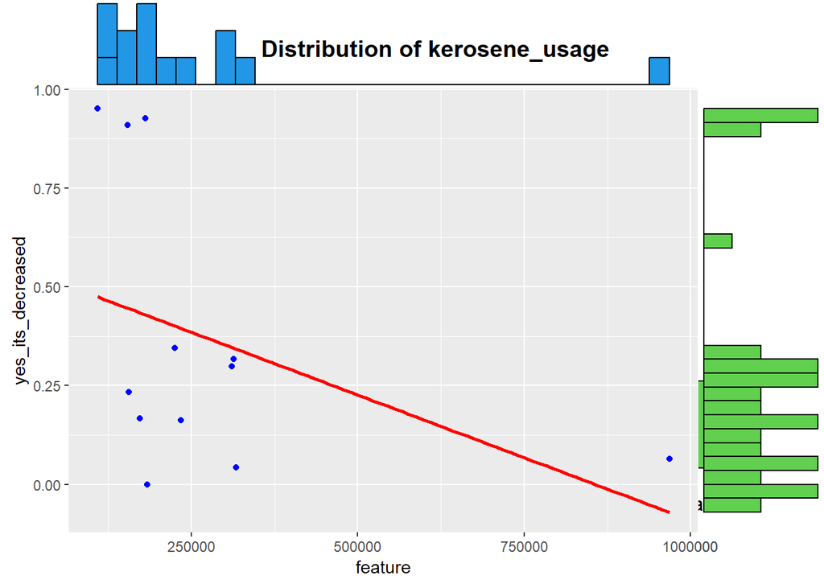

### TODO

- Does your Health Center have access to electricity?

## 4- Safety

### How safe do you feel outside your home when it is dark?

**Value (Encoding if applied)**: “Very unsafe” = 1; “Somewhat unsafe” = 2; “Neither safe nor unsafe”= 3; “Somewhat safe” = 4; “Very safe” = 5

**Hypothesis Testing:**

- ${H_0}$ = No relationship between any independent variable (as described above) and increase in feeling of safety
- ${H_1}$ = A relationship between any independent variable (as described above) and increase in feeling of safety

```r
pre_scores <- paired_enc$feel_safe_dark_pre
post_scores <- paired_enc$feel_safe_dark_post
diff <- post_scores - pre_scores

# Running the test
# wilcox.test(pre_scores, post_scores, paired=TRUE)
signtest(diff, m=0, conf.level=0.95, exact=FALSE)
```

```
##
##  Large Sample Approximation for the Sign Test
##
##  H0: The population median is =  0
##  HA: The population median is not equal to  0
##
##  B = 33
##
##  Significance Level = 0.05
##  The p-value is  0.434724000728643
##  There is not enough evidence to conclude that the population median is different than 0 at a significance level of  0.05
##
##  The  95 % confidence interval is [ -1 ,  0 ].
##
```

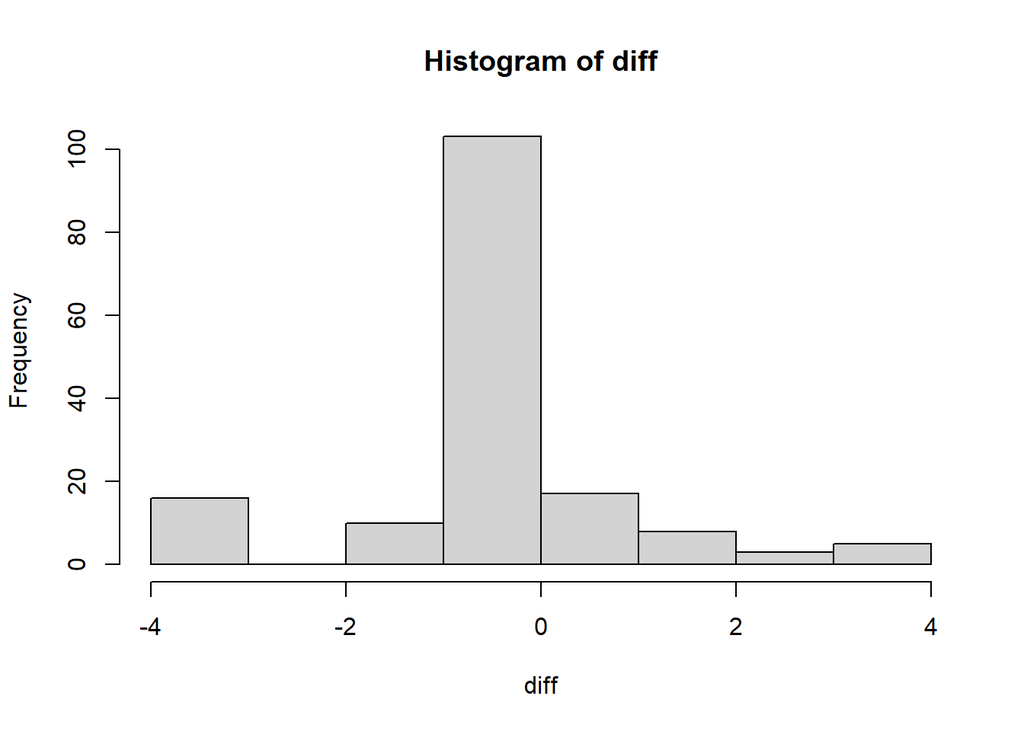

```r
# Visualize distribution of score differences
hist(diff)
```

### TODO

- What makes you feel the most unsafe?
- Does your community currently have outdoor community lights?
- How safe would you feel outside your home at nighttime IF you had exterior lights?

## 5- Economic Activity

### What is your average monthly household income?

**Data Source**: Paired Household Surveys (Pre & Post)

**Value (Encoding if applied)**: Any numeric value

**Hypothesis Testing:**

- ${H_0}$ = No difference between pre and post average household income
- ${H_1}$ = A significant difference between pre and post average household income

```r
# Running the paired t-test
income_pre <- paired_clean$avg_household_income_pre
income_post <- paired_clean$avg_household_income_post
t.test(income_pre, income_post,
       paired = TRUE, alternative = "two.sided")
```

```
##
##  Paired t-test
##
## data:  income_pre and income_post
## t = 0.44468, df = 160, p-value = 0.6572
## alternative hypothesis: true mean difference is not equal to 0
## 95 percent confidence interval:
##  -27.80728  43.96877
## sample estimates:
## mean difference
##        8.080745
```

### Has your household income changed since your connection to mini-grid power?

**Data Source**: Household Post Survey

**Value (Encoding if applied)**: “Yes, it’s decreased” = -1; “No, it’s the same” = 0; “Yes, it’s increased” = 1

**Hypothesis Testing:**

- ${H_0}$ = No relationship between any independent variable (as described above) and decrease in household income change
- ${H_1}$ = A relationship between any independent variable (as described above) and decrease in household income change

```r
# Isolate the dependent variable
var <- post_hs$household_income_change
income_change <- var[var != ""]

tab1(income_change,
     sort.group = "decreasing", cum.percent = TRUE)
```

```
## income_change :
##                      Frequency Percent Cum. percent
## no_it_is_the_same          721    68.0         68.0
## yes_it_has_increased       316    29.8         97.7
## yes_it_has_decreased        24     2.3        100.0
##   Total                   1061   100.0        100.0
```

```r
# Breakdown by response type and Community
dep_var_mat <- rownames_to_column(
  as.data.frame.matrix(prop.table(table(post_hs$community,
                                   post_hs$household_income_change),
                                         margin = 1)
                                                  )
                                      , var = "community")
community_data <- merge(x=projects, y=dep_var_mat, by="community")
reg_df <- community_data
# reg_df <- community_data %>% filter(community != "kalobeyei_settlement")

ind_vars <- reg_df[c(4:6)]

## Linear Regression t-Test
# Model with increase
reg_increase <- function(feature) {
  ## Fitting the model with reported increase
  # PV Size (kwH)
  lm <- lm(yes_it_has_increased ~ feature, data=reg_df)
  print(summary(lm))

  # Visualizing
  scatter <- ggplot(data = reg_df,
                    aes(feature, yes_it_has_increased)) +
                    geom_point(color='blue') +
                    geom_smooth(color='red', method = "lm", se = FALSE)
                    theme_classic()
  ggMarginal(scatter, type = "histogram",
             xparams = list(fill = 4),
             yparams = list(fill = 3))
}

reg_decrease <- function(feature) {
  ## Fitting the model with reported increase
  # PV Size (kwH)
  lm <- lm(yes_it_has_decreased ~ feature, data=reg_df)
  print(summary(lm))

  # Visualizing
  scatter <- ggplot(data = reg_df,
                    aes(feature, yes_it_has_decreased)) +
                    geom_point(color='blue') +
                    geom_smooth(color='red', method = "lm", se = FALSE)
                    theme_classic()
  ggMarginal(scatter, type = "histogram",
             xparams = list(fill = 4),
             yparams = list(fill = 3))
}

sapply(ind_vars, reg_increase)
```

```
##
## Call:
## lm(formula = yes_it_has_increased ~ feature, data = reg_df)
##
## Residuals:
##      Min       1Q   Median       3Q      Max
## -0.35750 -0.22368 -0.06111  0.24589  0.41903
##
## Coefficients:
##               Estimate Std. Error t value Pr(>|t|)
## (Intercept)  0.3666665  0.0910329   4.028  0.00241 **
## feature     -0.0004899  0.0005731  -0.855  0.41266
## ---
## Signif. codes:  0 '***' 0.001 '**' 0.01 '*' 0.05 '.' 0.1 ' ' 1
##
## Residual standard error: 0.2828 on 10 degrees of freedom
## Multiple R-squared:  0.0681, Adjusted R-squared:  -0.02509
## F-statistic: 0.7307 on 1 and 10 DF,  p-value: 0.4127
```

```
##
## Call:
## lm(formula = yes_it_has_increased ~ feature, data = reg_df)
##
## Residuals:
##     Min      1Q  Median      3Q     Max
## -0.3465 -0.2345 -0.0633  0.2366  0.3966
##
## Coefficients:
##               Estimate Std. Error t value Pr(>|t|)
## (Intercept)  0.3782326  0.0907776   4.167  0.00193 **
## feature     -0.0001198  0.0001114  -1.075  0.30756
## ---
## Signif. codes:  0 '***' 0.001 '**' 0.01 '*' 0.05 '.' 0.1 ' ' 1
##
## Residual standard error: 0.2773 on 10 degrees of freedom
## Multiple R-squared:  0.1036, Adjusted R-squared:  0.01398
## F-statistic: 1.156 on 1 and 10 DF,  p-value: 0.3076
```

```
##
## Call:
## lm(formula = yes_it_has_increased ~ feature, data = reg_df)
##
## Residuals:
##     Min      1Q  Median      3Q     Max
## -0.3616 -0.2306 -0.0595  0.2360  0.4409
##
## Coefficients:
##                  Estimate    Std. Error t value Pr(>|t|)
## (Intercept)  0.4192715103  0.1319934613   3.176  0.00988 **
## feature     -0.0000003142  0.0000003740  -0.840  0.42058
## ---
## Signif. codes:  0 '***' 0.001 '**' 0.01 '*' 0.05 '.' 0.1 ' ' 1
##
## Residual standard error: 0.2831 on 10 degrees of freedom
## Multiple R-squared:  0.0659, Adjusted R-squared:  -0.02751
## F-statistic: 0.7055 on 1 and 10 DF,  p-value: 0.4206
```

```r
sapply(ind_vars, reg_decrease)
```

```
##
## Call:
## lm(formula = yes_it_has_decreased ~ feature, data = reg_df)
##
## Residuals:
##       Min        1Q    Median        3Q       Max
## -0.023359 -0.022432 -0.022128  0.006658  0.116608
##
## Coefficients:
##               Estimate Std. Error t value Pr(>|t|)
## (Intercept) 0.02147120 0.01378062   1.558     0.15
## feature     0.00003679 0.00008675   0.424     0.68
##
## Residual standard error: 0.0428 on 10 degrees of freedom
## Multiple R-squared:  0.01767,    Adjusted R-squared:  -0.08056
## F-statistic: 0.1799 on 1 and 10 DF,  p-value: 0.6805
```

```
##
## Call:
## lm(formula = yes_it_has_decreased ~ feature, data = reg_df)
##
## Residuals:
##       Min        1Q    Median        3Q       Max
## -0.023116 -0.022224 -0.021557  0.005393  0.116936
##
## Coefficients:
##                Estimate  Std. Error t value Pr(>|t|)
## (Intercept) 0.021019178 0.013989307   1.503    0.164
## feature     0.000007911 0.000017167   0.461    0.655
##
## Residual standard error: 0.04273 on 10 degrees of freedom
## Multiple R-squared:  0.0208, Adjusted R-squared:  -0.07712
## F-statistic: 0.2124 on 1 and 10 DF,  p-value: 0.6548
```

```
##
## Call:
## lm(formula = yes_it_has_decreased ~ feature, data = reg_df)
##
## Residuals:
##       Min        1Q    Median        3Q       Max
## -0.024888 -0.022327 -0.021515  0.008376  0.117013
##
## Coefficients:
##                  Estimate    Std. Error t value Pr(>|t|)
## (Intercept) 0.01828368189 0.02000165672   0.914    0.382
## feature     0.00000002084 0.00000005668   0.368    0.721
##
## Residual standard error: 0.0429 on 10 degrees of freedom
## Multiple R-squared:  0.01334,    Adjusted R-squared:  -0.08533
## F-statistic: 0.1352 on 1 and 10 DF,  p-value: 0.7208
```

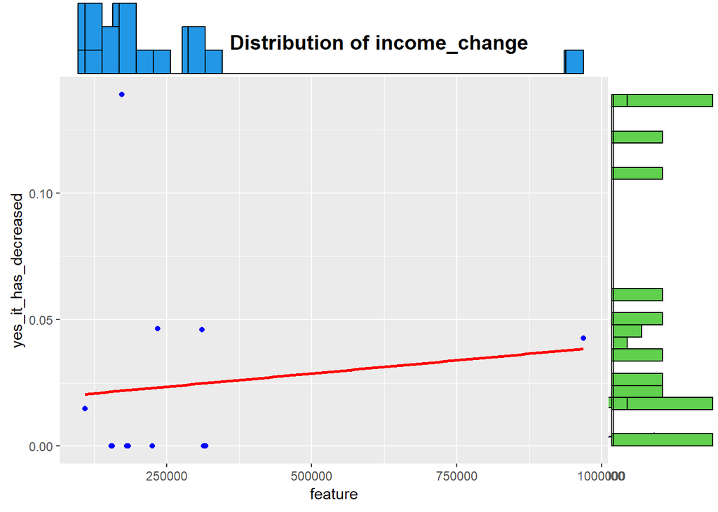

### Are any household members business owners?

**Data Source**: Paired Household Surveys (Pre & Post)

**Value (Encoding if applied)**: “None” = 0; “Not None” = 1

**Hypothesis Testing:**

- ${H_0}$ = No difference between pre and post presence of new local business owners
- ${H_1}$ = A significant difference between pre and post presence of new local business owners

```r
## McNemar's Test
# Cross tabulation of changes between business ownership
cross_tab <- table(paired_enc$business_owners_binary_pre,
                   paired_enc$business_owners_binary_post)
cross_tab
```

```
##
##      0  1
##   0 72 52
##   1  8 30
```

```r
# Running the test
mcnemar.test(cross_tab)
```

```
##
##  McNemar's Chi-squared test with continuity correction
##
## data:  cross_tab
## McNemar's chi-squared = 30.817, df = 1, p-value = 0.00000002836
```

```r
# Change
paired_enc$biz_change <- paired_enc$business_owners_binary_post - paired_enc$business_owners_binary_pre

# Breakdown by response type and Community
dep_var_mat <- rownames_to_column(as.data.frame.matrix(
                                      prop.table(table(
                                          paired_enc$community_post,
                                          paired_enc$biz_change),
                                         margin = 1)
                                                  )
                                      , var = "community")
community_data <- merge(x=projects, y=dep_var_mat, by="community")
reg_df <- community_data
names(reg_df)[7] <- "var_decrease"
names(reg_df)[8] <- "var_neutral"
names(reg_df)[9] <- "var_increase"
#
ind_vars <- reg_df[c(4:6)]

## Linear Regression t-Test
# Model with increase
reg_increase <- function(feature) {
  ## Fitting the model with reported increase
  # PV Size (kwH)
  lm <- lm(var_increase ~ feature, data=reg_df)
  print(summary(lm))

  # Visualizing
  scatter <- ggplot(data = reg_df,
                    aes(feature, var_increase)) +
                    geom_point(color='blue') +
                    geom_smooth(color='red', method = "lm", se = FALSE)
                    theme_classic()
  ggMarginal(scatter, type = "histogram",
             xparams = list(fill = 4),
             yparams = list(fill = 3))
}

reg_decrease <- function(feature) {
  ## Fitting the model with reported increase
  # PV Size (kwH)
  lm <- lm(var_decrease ~ feature, data=reg_df)
  print(summary(lm))

  # Visualizing
  scatter <- ggplot(data = reg_df,
                    aes(feature, var_decrease)) +
                    geom_point(color='blue') +
                    geom_smooth(color='red', method = "lm", se = FALSE)
                    theme_classic()
  ggMarginal(scatter, type = "histogram",
             xparams = list(fill = 4),
             yparams = list(fill = 3))
}

sapply(ind_vars, reg_increase)
```

```
##
## Call:
## lm(formula = var_increase ~ feature, data = reg_df)
##
## Residuals:
##      Min       1Q   Median       3Q      Max
## -0.39473 -0.16826  0.01756  0.10307  0.59282
##
## Coefficients:
##               Estimate Std. Error t value Pr(>|t|)
## (Intercept)  0.4174522  0.1328063   3.143    0.020 *
## feature     -0.0008231  0.0006869  -1.198    0.276
## ---
## Signif. codes:  0 '***' 0.001 '**' 0.01 '*' 0.05 '.' 0.1 ' ' 1
##
## Residual standard error: 0.3306 on 6 degrees of freedom
## Multiple R-squared:  0.1931, Adjusted R-squared:  0.0586
## F-statistic: 1.436 on 1 and 6 DF,  p-value: 0.276
```

```
##
## Call:
## lm(formula = var_increase ~ feature, data = reg_df)
##
## Residuals:
##      Min       1Q   Median       3Q      Max
## -0.39487 -0.17008  0.01807  0.09819  0.59676
##
## Coefficients:
##               Estimate Std. Error t value Pr(>|t|)
## (Intercept)  0.4275272  0.1358328   3.147   0.0199 *
## feature     -0.0001675  0.0001369  -1.223   0.2671
## ---
## Signif. codes:  0 '***' 0.001 '**' 0.01 '*' 0.05 '.' 0.1 ' ' 1
##
## Residual standard error: 0.3292 on 6 degrees of freedom
## Multiple R-squared:  0.1996, Adjusted R-squared:  0.06623
## F-statistic: 1.497 on 1 and 6 DF,  p-value: 0.2671
```

```
##
## Call:
## lm(formula = var_increase ~ feature, data = reg_df)
##
## Residuals:
##      Min       1Q   Median       3Q      Max
## -0.39862 -0.17096  0.05761  0.08419  0.51222
##
## Coefficients:
##                  Estimate    Std. Error t value Pr(>|t|)
## (Intercept)  0.5649357816  0.1697935447   3.327   0.0159 *
## feature     -0.0000007095  0.0000004193  -1.692   0.1415
## ---
## Signif. codes:  0 '***' 0.001 '**' 0.01 '*' 0.05 '.' 0.1 ' ' 1
##
## Residual standard error: 0.3028 on 6 degrees of freedom
## Multiple R-squared:  0.3231, Adjusted R-squared:  0.2103
## F-statistic: 2.864 on 1 and 6 DF,  p-value: 0.1415
```

```r
sapply(ind_vars, reg_decrease)
```

```
##
## Call:
## lm(formula = var_decrease ~ feature, data = reg_df)
##
## Residuals:
##      Min       1Q   Median       3Q      Max
## -0.10481 -0.10093 -0.07211  0.01192  0.39809
##
## Coefficients:
##               Estimate Std. Error t value Pr(>|t|)
## (Intercept)  0.1072053  0.0740649   1.447    0.198
## feature     -0.0001918  0.0003831  -0.501    0.634
##
## Residual standard error: 0.1844 on 6 degrees of freedom
## Multiple R-squared:  0.0401, Adjusted R-squared:  -0.1199
## F-statistic: 0.2506 on 1 and 6 DF,  p-value: 0.6345
```

```
##
## Call:
## lm(formula = var_decrease ~ feature, data = reg_df)
##
## Residuals:
##      Min       1Q   Median       3Q      Max
## -0.10301 -0.10130 -0.07254  0.00854  0.39907
##
## Coefficients:
##                Estimate  Std. Error t value Pr(>|t|)
## (Intercept)  0.10792139  0.07626525   1.415    0.207
## feature     -0.00003584  0.00007687  -0.466    0.658
##
## Residual standard error: 0.1849 on 6 degrees of freedom
## Multiple R-squared:  0.03496,    Adjusted R-squared:  -0.1259
## F-statistic: 0.2173 on 1 and 6 DF,  p-value: 0.6575
```

```
##
## Call:
## lm(formula = var_decrease ~ feature, data = reg_df)
##
## Residuals:
##      Min       1Q   Median       3Q      Max
## -0.10717 -0.09814 -0.06626 -0.00831  0.40357
##
## Coefficients:
##                   Estimate     Std. Error t value Pr(>|t|)
## (Intercept)  0.11645755459  0.10457561900   1.114    0.308
## feature     -0.00000008545  0.00000025822  -0.331    0.752
##
## Residual standard error: 0.1865 on 6 degrees of freedom
## Multiple R-squared:  0.01792,    Adjusted R-squared:  -0.1458
## F-statistic: 0.1095 on 1 and 6 DF,  p-value: 0.752
```

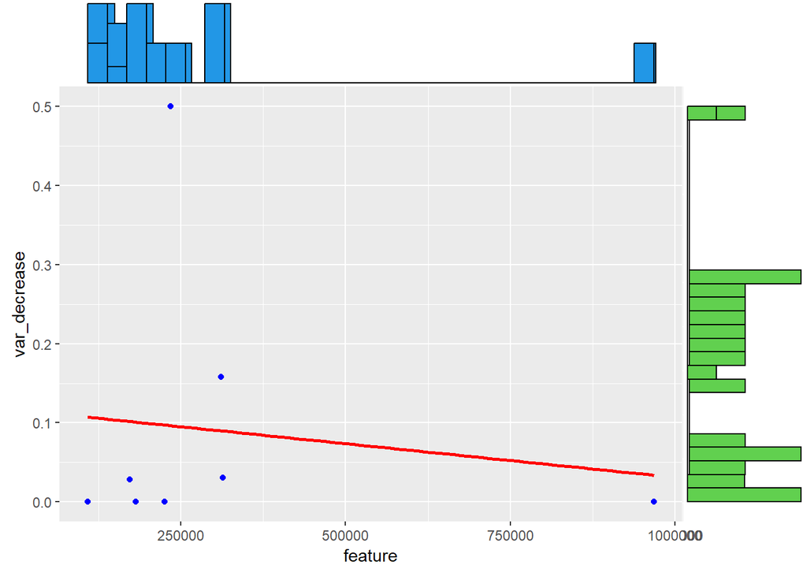

### TODO

- For businesses or shop owners only: Since connection to Renewvia mini-grid, have you seen any change in your weekly or monthly earnings?
- Since connection to Renewvia mini-grid, have you had any change in number of workers/employees at your place of work?